# Transcriptomic Biomarker Discovery and Machine Learning Classification in Acute Ischemic Stroke (GSE16561)

K. Sukikaran (2021/ASP/46)

2026-11-14

# 1. Environment Setup and Package Loading

This section installs and loads the required R and Bioconductor packages for data acquisition, preprocessing and statistical analysis.

```r
# Install Bioconductor manager if missing
if (!requireNamespace("BiocManager", quietly = TRUE)) {
  install.packages("BiocManager")
}

# Required Bioconductor packages
bioc_pkgs <- c(
  "GEOquery",
  "Biobase",
  "limma"
)

# Install missing packages
for (pkg in bioc_pkgs) {

  if (!requireNamespace(pkg, quietly = TRUE)) {

    BiocManager::install(
      pkg,
      ask = FALSE,
      update = FALSE
    )

  }

}

# Load required libraries
suppressPackageStartupMessages({
  library(GEOquery)
  library(Biobase)
  library(limma)
})

cat("Required packages loaded successfully.\n")
```

```
## Required packages loaded successfully.
```

```r
cat("GEOquery version:",
    as.character(packageVersion("GEOquery")), "\n")
```

```
## GEOquery version: 2.74.0
```

```r
cat("Biobase version:",
    as.character(packageVersion("Biobase")), "\n")
```

```
## Biobase version: 2.66.0
```

```r
cat("limma version:",
    as.character(packageVersion("limma")), "\n")
```

```
## limma version: 3.62.2
```

# 2. Data Acquisition and Import (NCBI GEO: GSE16561)

The GSE16561 dataset was obtained from the National Center for Biotechnology Information (NCBI) Gene Expression Omnibus (GEO).

The dataset contains peripheral whole-blood gene expression measurements from 39 acute ischemic stroke patients and 24 neurologically healthy control subjects.

The samples were analysed using the Illumina HumanRef-8 v3.0 Expression BeadChip platform (GPL6883).

## 2.1 Locate the Downloaded Dataset

```r
options(timeout = 600)

# Possible dataset files inside the project data folder
possible_paths <- file.path(
  data_dir,
  c(
    "GSE16561_series_matrix.txt",
    "GSE16561_series_matrix.txt.gz"
  )
)

available_paths <- possible_paths[
  file.exists(possible_paths)
]

# Download from NCBI GEO only if the file is missing
if (length(available_paths) == 0) {

  cat("Dataset not found locally. Downloading from NCBI GEO...\n")

  geo_url <- paste0(
    "https://ftp.ncbi.nlm.nih.gov/geo/series/",
    "GSE16nnn/GSE16561/matrix/",
    "GSE16561_series_matrix.txt.gz"
  )

  downloaded_file <- file.path(
    data_dir,
    "GSE16561_series_matrix.txt.gz"
  )

  download.file(
    url = geo_url,
    destfile = downloaded_file,
    mode = "wb",
    method = "libcurl"
  )

  if (!file.exists(downloaded_file)) {
    stop("Dataset download failed.")
  }

  file_to_use <- downloaded_file

} else {

  file_to_use <- available_paths[1]

}

cat("Dataset found at:", file_to_use, "\n")
```

```
## Dataset found at: C:/Users/ASUS/OneDrive/Desktop/BioAssignment/stroke-transcriptomics-gse16561/data/GSE16561_series_matrix.txt
```

## 2.2 Import GEO Expression Data

```r
# Cache the imported ExpressionSet inside data/
gse_rds <- file.path(
  data_dir,
  "GSE16561_raw_eSet.rds"
)

# Import the dataset or load the existing cache
if (file.exists(gse_rds)) {

  cat("Loading cached GEO dataset...\n")

  gse <- readRDS(gse_rds)

} else {

  cat("Importing GSE16561 Series Matrix...\n")

  gse_object <- GEOquery::getGEO(
    filename = file_to_use,
    getGPL = FALSE
  )

  if (inherits(gse_object, "ExpressionSet")) {

    gse <- gse_object

  } else if (is.list(gse_object) &&
             length(gse_object) > 0) {

    gse <- gse_object[[1]]

  } else {

    stop("Unexpected GEO dataset format.")

  }

  saveRDS(
    gse,
    file = gse_rds
  )

}
```

```
## Loading cached GEO dataset...
```

```r
# Extract expression and phenotype data
expr_raw <- Biobase::exprs(gse)

pdata_raw <- Biobase::pData(gse)

# Ensure a numeric expression matrix
expr_raw <- as.matrix(expr_raw)

storage.mode(expr_raw) <- "numeric"

cat(
  "Raw Expression Matrix Dimensions (Probes x Samples):",
  nrow(expr_raw), "x", ncol(expr_raw), "\n"
)
```

```
## Raw Expression Matrix Dimensions (Probes x Samples): 24424 x 63
```

```r
cat(
  "Number of clinical samples:",
  nrow(pdata_raw), "\n"
)
```

```
## Number of clinical samples: 63
```

# 3. Quality Control, Preprocessing and Gene Annotation

This section performs initial quality control, clinical sample classification, missing-value handling and probe annotation.

The submitted GSE16561 expression values have already undergone background correction, quantile normalization and log2 summarisation using RMA processing. Therefore, no additional log2 transformation or quantile normalization is applied.

## 3.1 Clinical Metadata Cleaning

```r
# Extract GEO sample identifiers
sample_ids <- as.character(
  pdata_raw$geo_accession
)

# Match metadata to the order of the expression matrix
sample_index <- match(
  colnames(expr_raw),
  sample_ids
)

if (anyNA(sample_index)) {
  stop("Could not match sample identifiers.")
}

# Reorder metadata to match expression columns
pdata_ordered <- pdata_raw[
  sample_index,
  ,
  drop = FALSE
]

sample_ids <- sample_ids[sample_index]

# Combine sample description fields
text_columns <- vapply(
  pdata_ordered,
  function(x) is.character(x) || is.factor(x),
  logical(1)
)

sample_description <- apply(
  as.data.frame(
    lapply(
      pdata_ordered[, text_columns, drop = FALSE],
      as.character
    )
  ),
  1,
  paste,
  collapse = " "
)

# Avoid interpreting non-stroke as stroke
sample_description <- gsub(
  "non[- ]stroke",
  " ",
  sample_description,
  ignore.case = TRUE
)

# Identify stroke and control samples
stroke_flag <- grepl(
  "\\bstroke\\b|ischemic",
  sample_description,
  ignore.case = TRUE
)

control_flag <- grepl(
  "\\bcontrol\\b|healthy",
  sample_description,
  ignore.case = TRUE
)

# Detect ambiguous sample classifications
if (any(stroke_flag == control_flag)) {

  print(
    sample_description[stroke_flag == control_flag]
  )

  stop("Some samples could not be classified correctly.")

}

# Create the clinical metadata table
metadata <- data.frame(
  Sample_ID = sample_ids,
  Title = as.character(pdata_ordered$title),
  Group = ifelse(
    stroke_flag,
    "Stroke",
    "Control"
  ),
  stringsAsFactors = FALSE
)

metadata$Group <- factor(
  metadata$Group,
  levels = c("Control", "Stroke")
)

rownames(metadata) <- metadata$Sample_ID

# Display group distribution
cat("Clinical Sample Distribution:\n")
```

```
## Clinical Sample Distribution:
```

```r
group_counts <- table(metadata$Group)

print(group_counts)
```

```
##
## Control  Stroke
##      24      39
```

```r
# Verify expected sample counts
if (
  group_counts["Control"] != 24 ||
  group_counts["Stroke"] != 39
) {

  stop("Expected 24 Control and 39 Stroke samples.")

}

cat("Clinical metadata verification successful.\n")
```

```
## Clinical metadata verification successful.
```

## 3.2 Missing Value Inspection and Filtering

```r
# Count original missing values
na_count <- sum(is.na(expr_raw))

missing_percentage <- (
  na_count / length(expr_raw)
) * 100

cat(
  "Missing values before filtering:",
  na_count, "\n"
)
```

```
## Missing values before filtering: 24427
```

```r
cat(
  "Missing percentage:",
  round(missing_percentage, 3), "%\n"
)
```

```
## Missing percentage: 1.587 %
```

```r
# Calculate missing-value proportion for each probe
missing_fraction <- rowMeans(
  is.na(expr_raw)
)

# Identify probes containing at least one valid observation
nonempty_probes <- rowSums(
  !is.na(expr_raw)
) > 0

# Retain probes with no more than 20% missing values
keep_probes <- (
  missing_fraction <= 0.20
) & nonempty_probes

expr_clean <- expr_raw[
  keep_probes,
  ,
  drop = FALSE
]

cat(
  "Probes before filtering:",
  nrow(expr_raw), "\n"
)
```

```
## Probes before filtering: 24424
```

```r
cat(
  "Probes retained:",
  nrow(expr_clean), "\n"
)
```

```
## Probes retained: 24424
```

```r
cat(
  "Probes removed:",
  nrow(expr_raw) - nrow(expr_clean), "\n"
)
```

```
## Probes removed: 0
```

```r
# Calculate median expression for each probe
row_medians <- apply(
  expr_clean,
  1,
  median,
  na.rm = TRUE
)

# Identify rows requiring imputation
missing_rows <- which(
  rowSums(is.na(expr_clean)) > 0
)

# Replace missing values with row medians
for (i in missing_rows) {

  missing_index <- is.na(
    expr_clean[i, ]
  )

  expr_clean[i, missing_index] <- row_medians[i]

}

# Verify missing-value handling
cat(
  "Missing values after imputation:",
  sum(is.na(expr_clean)), "\n"
)
```

```
## Missing values after imputation: 0
```

```r
if (anyNA(expr_clean)) {
  stop("Missing values remain after preprocessing.")
}
```

## 3.3 Expression Scale Inspection

```r
# Calculate expression value quantiles
expression_quantiles <- quantile(
  expr_clean,
  probs = c(0, 0.25, 0.50, 0.75, 0.99, 1),
  na.rm = TRUE
)

cat("Expression Value Quantiles:\n")
```

```
## Expression Value Quantiles:
```

```r
print(expression_quantiles)
```

```
##            0%           25%           50%           75%           99%
## -6.235401e+00 -2.381444e-01 -2.932545e-05  2.138945e-01  9.719757e-01
##          100%
##  6.100933e+00
```

```r
cat(
  "Minimum expression:",
  min(expr_clean), "\n"
)
```

```
## Minimum expression: -6.235401
```

```r
cat(
  "Maximum expression:",
  max(expr_clean), "\n"
)
```

```
## Maximum expression: 6.100933
```

```r
cat(
  "Mean expression:",
  mean(expr_clean), "\n"
)
```

```
## Mean expression: -0.01210419
```

```r
# Retain the GEO-processed expression values
expr_processed <- expr_clean

cat(
  "Existing log2 and quantile-normalized values retained.\n"
)
```

```
## Existing log2 and quantile-normalized values retained.
```

```r
cat(
  "Additional normalization was not applied.\n"
)
```

```
## Additional normalization was not applied.
```

## 3.4 Retrieve GPL6883 Platform Annotation

The GPL6883 platform annotation is used to identify the official gene symbols corresponding to Illumina probe identifiers.

```r
# Platform annotation file inside the project
gpl_file <- file.path(
  data_dir,
  "GPL6883.annot.gz"
)

# NCBI GEO annotation download URL
gpl_url <- paste0(
  "https://ftp.ncbi.nlm.nih.gov/geo/platforms/",
  "GPL6nnn/GPL6883/annot/GPL6883.annot.gz"
)

# Download annotation only if missing
if (!file.exists(gpl_file)) {

  cat("Downloading GPL6883 annotation...\n")

  download.file(
    url = gpl_url,
    destfile = gpl_file,
    mode = "wb",
    method = "libcurl"
  )

}

if (
  !file.exists(gpl_file) ||
  file.info(gpl_file)$size < 1000
) {

  stop("GPL6883 annotation file is missing or incomplete.")

}

cat("GPL6883 annotation file located successfully.\n")
```

```
## GPL6883 annotation file located successfully.
```

```r
# Read the annotation header
con <- gzfile(
  gpl_file,
  open = "rt"
)

header_lines <- readLines(
  con,
  n = 500
)

close(con)

header_index <- grep(
  "^#?ID\\t",
  header_lines
)[1]

if (is.na(header_index)) {
  stop("GPL6883 annotation header was not found.")
}

# Import the complete annotation table
con <- gzfile(
  gpl_file,
  open = "rt"
)

gpl_table <- read.delim(
  con,
  header = TRUE,
  sep = "\t",
  skip = header_index - 1,
  quote = "",
  comment.char = "",
  fill = TRUE,
  check.names = FALSE,
  stringsAsFactors = FALSE
)

close(con)

# Clean column names
colnames(gpl_table) <- sub(
  "^#",
  "",
  colnames(gpl_table)
)

cat(
  "Platform annotation dimensions:",
  nrow(gpl_table), "x", ncol(gpl_table), "\n"
)
```

```
## Platform annotation dimensions: 24527 x 22
```

```r
cat("Available annotation columns:\n")
```

```
## Available annotation columns:
```

```r
print(colnames(gpl_table))
```

```
##  [1] "ID"                    "Gene title"            "Gene symbol"
##  [4] "Gene ID"               "UniGene title"         "UniGene symbol"
##  [7] "UniGene ID"            "Nucleotide Title"      "GI"
## [10] "GenBank Accession"     "Platform_CLONEID"      "Platform_ORF"
## [13] "Platform_SPOTID"       "Chromosome location"   "Chromosome annotation"
## [16] "GO:Function"           "GO:Process"            "GO:Component"
## [19] "GO:Function ID"        "GO:Process ID"         "GO:Component ID"
## [22] "Platform_SEQUENCE"
```

## 3.5 Gene Symbol Mapping and Probe Summarisation

```r
# Identify annotation columns
id_col <- "ID"

symbol_col <- "Gene symbol"

# Verify columns
stopifnot(
  id_col %in% colnames(gpl_table),
  symbol_col %in% colnames(gpl_table)
)

# Match expression probes with GPL6883 annotation
probe_index <- match(
  rownames(expr_processed),
  as.character(gpl_table[[id_col]])
)

# Extract gene symbols
probe_symbols <- as.character(
  gpl_table[[symbol_col]][probe_index]
)

probe_symbols <- trimws(probe_symbols)

cat(
  "Successfully matched probes:",
  sum(!is.na(probe_symbols)), "\n"
)
```

```
## Successfully matched probes: 24424
```

```r
cat(
  "Unmatched probes:",
  sum(is.na(probe_symbols)), "\n"
)
```

```
## Unmatched probes: 0
```

```r
# Handle multiple gene symbols assigned to probes
gene_symbols <- sub(
  "\\s*///.*$",
  "",
  probe_symbols
)

gene_symbols <- trimws(gene_symbols)

# Identify valid gene annotations
valid_probes <- !is.na(gene_symbols) &
  gene_symbols != "" &
  !toupper(gene_symbols) %in% c(
    "---", "NA", "NONE", "NULL"
  )

# Retain successfully annotated probes
expr_annotated <- expr_processed[
  valid_probes,
  ,
  drop = FALSE
]

gene_symbols_valid <- gene_symbols[
  valid_probes
]

cat(
  "Valid annotated probes:",
  nrow(expr_annotated), "\n"
)
```

```
## Valid annotated probes: 22641
```

```r
# Summarise duplicate probes using mean expression
expr_gene <- limma::avereps(
  expr_annotated,
  ID = gene_symbols_valid
)

cat(
  "Final Cleaned Gene Matrix (Unique Genes x Samples):",
  nrow(expr_gene), "x", ncol(expr_gene), "\n"
)
```

```
## Final Cleaned Gene Matrix (Unique Genes x Samples): 17494 x 63
```

## 3.6 Final Quality Checks

```r
# Match metadata to expression matrix columns
metadata <- metadata[
  match(
    colnames(expr_gene),
    metadata$Sample_ID
  ),
  ,
  drop = FALSE
]

# Verify sample matching
if (anyNA(metadata$Sample_ID)) {
  stop("Sample matching failed.")
}

# Check final matrix
cat(
  "Final missing values:",
  sum(is.na(expr_gene)), "\n"
)
```

```
## Final missing values: 0
```

```r
cat(
  "Duplicate gene symbols:",
  sum(duplicated(rownames(expr_gene))), "\n"
)
```

```
## Duplicate gene symbols: 0
```

```r
cat(
  "Final gene count:",
  nrow(expr_gene), "\n"
)
```

```
## Final gene count: 17494
```

```r
cat(
  "Final sample count:",
  ncol(expr_gene), "\n"
)
```

```
## Final sample count: 63
```

```r
cat("Final sample distribution:\n")
```

```
## Final sample distribution:
```

```r
print(table(metadata$Group))
```

```
##
## Control  Stroke
##      24      39
```

```r
# Validate final dataset
stopifnot(
  is.matrix(expr_gene),
  is.numeric(expr_gene),
  !anyNA(expr_gene),
  !anyDuplicated(rownames(expr_gene)),
  ncol(expr_gene) == 63,
  sum(metadata$Group == "Control") == 24,
  sum(metadata$Group == "Stroke") == 39
)

cat("All quality checks completed successfully.\n")
```

```
## All quality checks completed successfully.
```

## 3.7 Export Cleaned Data and Metadata

```r
# Export clinical metadata
write.csv(
  metadata,
  file.path(
    data_dir,
    "GSE16561_clinical_metadata.csv"
  ),
  row.names = FALSE
)

# Export annotated gene expression matrix
write.csv(
  expr_gene,
  file.path(
    data_dir,
    "GSE16561_gene_expression_matrix.csv"
  ),
  quote = FALSE
)

# Save combined cleaned dataset
saveRDS(
  list(
    expr = expr_gene,
    metadata = metadata
  ),
  file.path(
    data_dir,
    "GSE16561_cleaned_data.rds"
  )
)

# Create quality control summary
qc_summary <- data.frame(
  Metric = c(
    "Original probes",
    "Original samples",
    "Original missing values",
    "Missing value percentage",
    "Probes retained after filtering",
    "Annotated probes",
    "Unique genes",
    "Control samples",
    "Stroke samples",
    "Final missing values"
  ),

  Value = c(
    nrow(expr_raw),
    ncol(expr_raw),
    na_count,
    round(missing_percentage, 3),
    nrow(expr_clean),
    nrow(expr_annotated),
    nrow(expr_gene),
    24,
    39,
    sum(is.na(expr_gene))
  )
)

write.csv(
  qc_summary,
  file.path(
    data_dir,
    "GSE16561_QC_summary.csv"
  ),
  row.names = FALSE
)

cat("Cleaned data exported successfully.\n")
```

```
## Cleaned data exported successfully.
```

```r
cat("Generated files:\n")
```

```
## Generated files:
```

```r
print(
  list.files(
    data_dir,
    full.names = FALSE
  )
)
```

```
##  [1] "GPL6883.annot.gz"
##  [2] "GSE16561_annotated_DEG_results.csv"
##  [3] "GSE16561_cleaned_data.rds"
##  [4] "GSE16561_clinical_metadata.csv"
##  [5] "GSE16561_DEG_summary.csv"
##  [6] "GSE16561_differential_expression_all_genes.csv"
##  [7] "GSE16561_EDA_summary.csv"
##  [8] "GSE16561_enrichment_gene_sets.csv"
##  [9] "GSE16561_enrichment_gene_sets.rds"
## [10] "GSE16561_enrichment_mapping_summary.csv"
## [11] "GSE16561_enrichment_summary.csv"
## [12] "GSE16561_functional_enrichment_results.rds"
## [13] "GSE16561_gene_expression_matrix.csv"
## [14] "GSE16561_gene_id_mapping.csv"
## [15] "GSE16561_go_bp_all_enrichment.csv"
```

[output cut: 24 more lines]

# 4. Exploratory Data Analysis (EDA)

Exploratory Data Analysis is performed to investigate the distribution and variation of gene expression values and identify patterns among the clinical samples.

The analysis includes expression distribution boxplots, density plots, Principal Component Analysis (PCA), and sample-to-sample correlation analysis.

The cleaned gene expression matrix containing 17,494 unique genes and 63 clinical samples is used.

## 4.1 Data Preparation

```r
# Load visualization packages
if (!requireNamespace("ggplot2", quietly = TRUE)) {
  install.packages("ggplot2")
}

if (!requireNamespace("pheatmap", quietly = TRUE)) {
  install.packages("pheatmap")
}

library(ggplot2)
library(pheatmap)

# Verify cleaned expression matrix
stopifnot(
  ncol(expr_gene) == 63,
  nrow(metadata) == 63,
  !anyNA(expr_gene)
)

# Match metadata to expression samples
metadata <- metadata[
  match(
    colnames(expr_gene),
    metadata$Sample_ID
  ),
  ,
  drop = FALSE
]

# Verify sample alignment
stopifnot(
  identical(
    colnames(expr_gene),
    metadata$Sample_ID
  )
)

# Display group distribution
print(table(metadata$Group))
```

```
##
## Control  Stroke
##      24      39
```

```r
# Define group colours
group_colors <- c(
  "Control" = "#2C7BB6",
  "Stroke" = "#D7191C"
)

# Ensure figures directory exists
dir.create(
  figure_dir,
  showWarnings = FALSE,
  recursive = TRUE
)

cat("EDA preparation completed successfully.\n")
```

```
## EDA preparation completed successfully.
```

## 4.2 Gene Expression Distribution Across Samples

A boxplot is used to compare the distribution of gene expression values across all 63 samples. This helps identify differences in expression distributions and potential outliers among the samples.

```r
# Create sample colours based on clinical groups
sample_colors <- unname(
  group_colors[as.character(metadata$Group)]
)

# Define output file
boxplot_file <- file.path(
  figure_dir,
  "fig1_expression_boxplot.png"
)

# Save the boxplot with a white background
png(
  filename = boxplot_file,
  width = 2800,
  height = 1500,
  res = 200,
  bg = "white"
)

par(mar = c(11, 4, 4, 2) + 0.1)

boxplot(
  expr_gene,
  names = metadata$Sample_ID,
  las = 2,
  col = sample_colors,
  outline = FALSE,
  cex.axis = 0.55,
  ylab = "Log2 Gene Expression",
  xlab = "",
  main = "Gene Expression Distribution Across 63 Samples"
)

legend(
  "topright",
  legend = names(group_colors),
  fill = group_colors,
  title = "Clinical Group",
  cex = 0.8
)

dev.off()
```

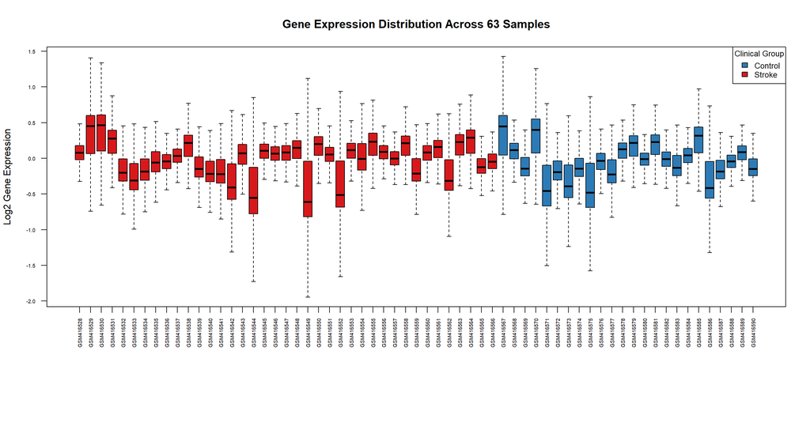

```r
# Display the saved figure in the report
knitr::include_graphics(boxplot_file)
```

## 4.3 Gene Expression Density Distribution

Density plots are used to examine the distribution of gene expression values across the clinical samples. A random sample of 3,000 genes is selected to make the visualisation manageable. The random seed is fixed to ensure reproducibility.

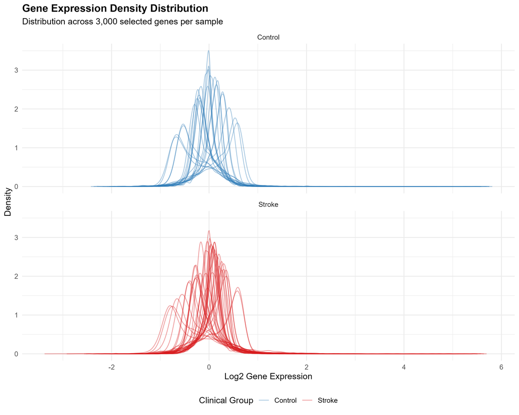

```r
# Set seed for reproducibility
set.seed(123)

# Randomly select 3,000 genes
selected_genes <- sample(
  seq_len(nrow(expr_gene)),
  size = min(3000, nrow(expr_gene))
)

# Calculate density for each sample
density_data <- do.call(
  rbind,
  lapply(seq_len(ncol(expr_gene)), function(i) {

    sample_density <- density(
      expr_gene[selected_genes, i],
      na.rm = TRUE
    )

    data.frame(
      Expression = sample_density$x,
      Density = sample_density$y,
      Sample_ID = colnames(expr_gene)[i],
      Group = as.character(metadata$Group[i])
    )
  })
)

# Set clinical group order
density_data$Group <- factor(
  density_data$Group,
  levels = c("Control", "Stroke")
)

# Create density plot
density_plot <- ggplot2::ggplot(
  density_data,
  ggplot2::aes(
    x = Expression,
    y = Density,
    group = Sample_ID,
    colour = Group
  )
) +
  ggplot2::geom_line(
    alpha = 0.4,
    linewidth = 0.5
  ) +
  ggplot2::facet_wrap(~Group, ncol = 1) +
  ggplot2::scale_colour_manual(values = group_colors) +
  ggplot2::labs(
    title = "Gene Expression Density Distribution",
    subtitle = "Distribution across 3,000 selected genes per sample",
    x = "Log2 Gene Expression",
    y = "Density",
    colour = "Clinical Group"
  ) +
  ggplot2::theme_minimal(base_size = 12) +
  ggplot2::theme(
    legend.position = "bottom",
    plot.title = ggplot2::element_text(face = "bold"),

    # White background for the complete figure
    plot.background = ggplot2::element_rect(
      fill = "white",
      colour = NA
    ),

    # White background for the plotting panels
    panel.background = ggplot2::element_rect(
      fill = "white",
      colour = NA
    )
  )

# Save the figure with a white background
density_file <- file.path(
  figure_dir,
  "fig2_expression_density.png"
)

ggplot2::ggsave(
  filename = density_file,
  plot = density_plot,
  width = 10,
  height = 8,
  dpi = 300,
  bg = "white"
)

# Display the saved figure in the report
knitr::include_graphics(density_file)
```

## 4.4 Principal Component Analysis (PCA)

Principal Component Analysis (PCA) is an unsupervised dimensionality reduction technique used to identify major patterns of variation in gene expression data. The 500 most variable genes are selected for this analysis. Each point in the PCA plot represents one clinical sample.

```r
# Calculate the variance of each gene
gene_variances <- apply(
  expr_gene,
  1,
  var
)

# Select the 500 most variable genes
top_variable_genes <- order(
  gene_variances,
  decreasing = TRUE
)[seq_len(min(500, length(gene_variances)))]

pca_matrix <- expr_gene[
  top_variable_genes,
  ,
  drop = FALSE
]

# Perform PCA using samples as observations
pca_result <- prcomp(
  t(pca_matrix),
  center = TRUE,
  scale. = FALSE
)

# Calculate percentage of variance explained
variance_explained <- (
  pca_result$sdev^2 /
  sum(pca_result$sdev^2)
) * 100

# Extract PC1 and PC2 scores
pca_scores <- data.frame(
  Sample_ID = rownames(pca_result$x),
  PC1 = pca_result$x[, 1],
  PC2 = pca_result$x[, 2],
  stringsAsFactors = FALSE
)

# Attach clinical group information
pca_scores$Group <- metadata$Group[
  match(pca_scores$Sample_ID, metadata$Sample_ID)
]

pca_scores$Group <- factor(
  pca_scores$Group,
  levels = c("Control", "Stroke")
)

# Verify that all PCA samples have matching clinical groups
stopifnot(
  nrow(pca_scores) == 63,
  !anyNA(pca_scores$Group)
)

# Display variance explained
cat(
  "PC1 variance explained:",
  round(variance_explained[1], 2), "%\n"
)
```

```
## PC1 variance explained: 48.12 %
```

```r
cat(
  "PC2 variance explained:",
  round(variance_explained[2], 2), "%\n"
)
```

```
## PC2 variance explained: 15.06 %
```

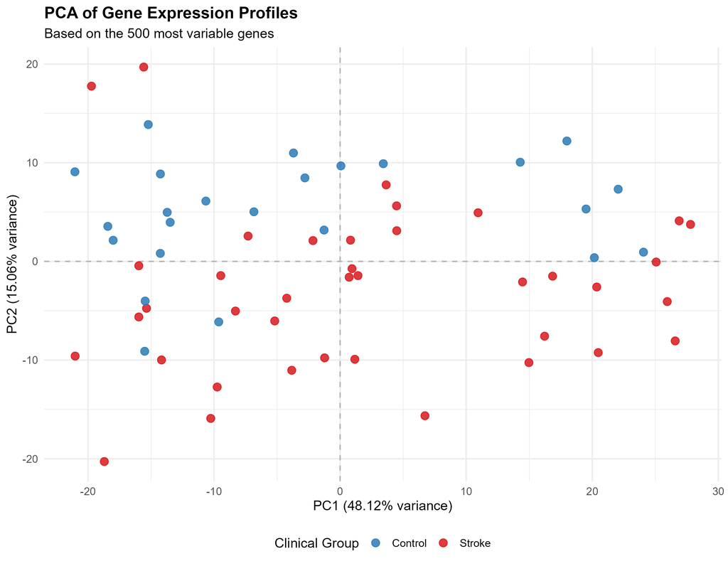

```r
# Create PCA plot
pca_plot <- ggplot2::ggplot(
  pca_scores,
  ggplot2::aes(
    x = PC1,
    y = PC2,
    colour = Group
  )
) +
  ggplot2::geom_hline(
    yintercept = 0,
    linetype = "dashed",
    colour = "grey70"
  ) +
  ggplot2::geom_vline(
    xintercept = 0,
    linetype = "dashed",
    colour = "grey70"
  ) +
  ggplot2::geom_point(
    size = 3,
    alpha = 0.85
  ) +
  ggplot2::scale_colour_manual(values = group_colors) +
  ggplot2::labs(
    title = "PCA of Gene Expression Profiles",
    subtitle = "Based on the 500 most variable genes",
    x = paste0(
      "PC1 (",
      round(variance_explained[1], 2),
      "% variance)"
    ),
    y = paste0(
      "PC2 (",
      round(variance_explained[2], 2),
      "% variance)"
    ),
    colour = "Clinical Group"
  ) +
  ggplot2::theme_minimal(base_size = 12) +
  ggplot2::theme(
    plot.title = ggplot2::element_text(face = "bold"),
    legend.position = "bottom",

    # White background for the complete figure
    plot.background = ggplot2::element_rect(
      fill = "white",
      colour = NA
    ),

    # White background for the plotting panel
    panel.background = ggplot2::element_rect(
      fill = "white",
      colour = NA
    )
  )

# Save PCA plot with a white background
pca_file <- file.path(
  figure_dir,
  "fig3_pca_plot.png"
)

ggplot2::ggsave(
  filename = pca_file,
  plot = pca_plot,
  width = 9,
  height = 7,
  dpi = 300,
  bg = "white"
)

# Export PCA scores
write.csv(
  pca_scores,
  file.path(
    data_dir,
    "GSE16561_PCA_scores.csv"
  ),
  row.names = FALSE
)

# Display plot in the report
knitr::include_graphics(pca_file)
```

## 4.5 Sample-to-Sample Correlation Analysis

Pearson correlation is used to measure the similarity of gene expression profiles between pairs of clinical samples. A sample-to-sample correlation matrix is generated and visualised using a heatmap. Higher positive correlation values indicate greater similarity in expression patterns.

```r
# Calculate Pearson correlation between samples
sample_correlation <- cor(
  expr_gene,
  method = "pearson"
)

# Create sample group annotation
sample_annotation <- data.frame(
  Group = metadata$Group
)

rownames(sample_annotation) <- metadata$Sample_ID

# Ensure annotation follows correlation matrix order
sample_annotation <- sample_annotation[
  rownames(sample_correlation),
  ,
  drop = FALSE
]

# Define output file
correlation_file <- file.path(
  figure_dir,
  "fig4_sample_correlation_heatmap.png"
)


# Generate a cleaner correlation heatmap
correlation_heatmap <- pheatmap(
  sample_correlation,
  color = colorRampPalette(
    c("#2166AC", "white", "#B2182B")
  )(100),
  breaks = seq(-1, 1, length.out = 101),

  # Show group annotation only once, across the top
  annotation_col = sample_annotation,
  annotation_colors = list(
    Group = group_colors
  ),
  annotation_names_col = FALSE,

  clustering_distance_rows = "euclidean",
  clustering_distance_cols = "euclidean",
  clustering_method = "complete",

  border_color = NA,
  show_rownames = FALSE,
  show_colnames = FALSE,

  treeheight_row = 40,
  treeheight_col = 40,

  main = "Sample-to-Sample Pearson Correlation",

silent = TRUE
)
# Save the heatmap using an explicitly managed device
grDevices::png(
  filename = correlation_file,
  width = 2400,
  height = 2200,
  res = 200,
  bg = "white"
)

grid::grid.newpage()
grid::grid.draw(correlation_heatmap$gtable)

grDevices::dev.off()
```

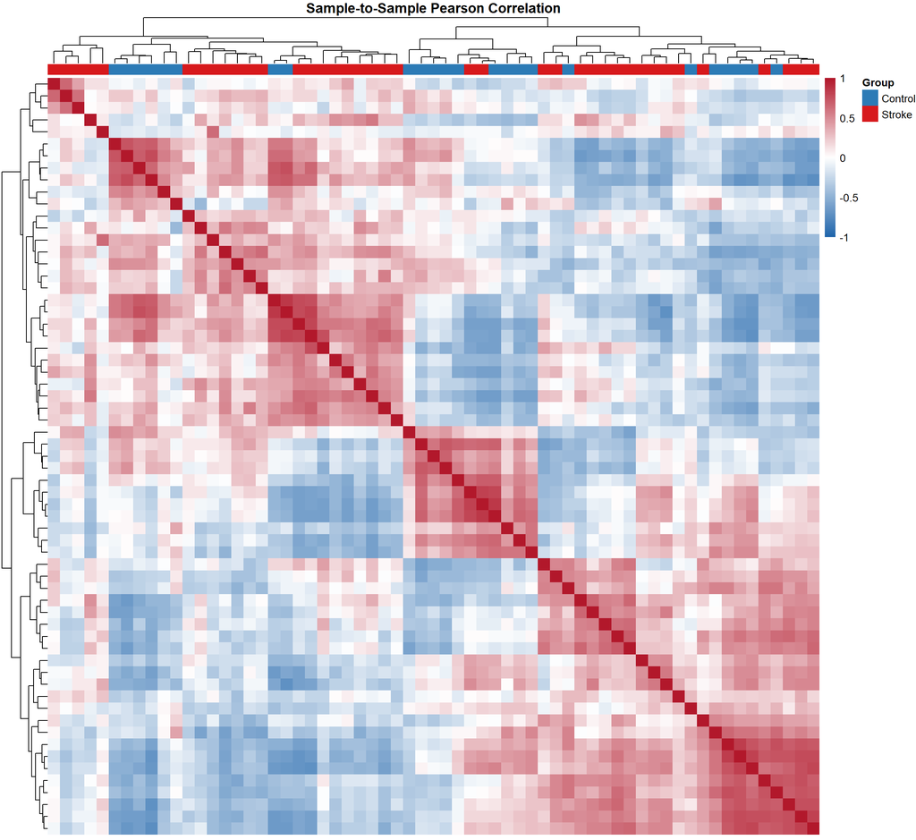

```r
# Export correlation matrix
write.csv(
  sample_correlation,
  file.path(
    data_dir,
    "GSE16561_sample_correlation.csv"
  )
)

# Display heatmap in the report
knitr::include_graphics(correlation_file)
```

## 4.6 Exploratory Data Analysis Summary

The EDA results are summarised using key dataset statistics, expression distribution measurements, PCA variance and sample correlation values. The generated figures and output files are also verified.

```r
# Calculate pairwise sample correlations
correlation_values <- sample_correlation[
  upper.tri(sample_correlation)
]

# Create EDA summary table
eda_summary <- data.frame(
  Metric = c(
    "Total unique genes",
    "Total clinical samples",
    "Control samples",
    "Stroke samples",
    "Mean gene expression",
    "Standard deviation of gene expression",
    "Minimum gene expression",
    "Maximum gene expression",
    "Number of genes used for PCA",
    "PC1 variance explained (%)",
    "PC2 variance explained (%)",
    "Mean sample correlation",
    "Minimum sample correlation",
    "Maximum sample correlation"
  ),

  Value = as.character(c(
    nrow(expr_gene),
    ncol(expr_gene),
    sum(metadata$Group == "Control"),
    sum(metadata$Group == "Stroke"),
    round(mean(expr_gene), 4),
    round(sd(as.vector(expr_gene)), 4),
    round(min(expr_gene), 4),
    round(max(expr_gene), 4),
    length(top_variable_genes),
    round(variance_explained[1], 2),
    round(variance_explained[2], 2),
    round(mean(correlation_values), 4),
    round(min(correlation_values), 4),
    round(max(correlation_values), 4)
  )),

  stringsAsFactors = FALSE
)

# Display summary table
knitr::kable(
  eda_summary,
  caption = "Exploratory Data Analysis Summary"
)
```

Exploratory Data Analysis Summary

| Metric | Value |
| --- | --- |
| Total unique genes | 17494 |
| Total clinical samples | 63 |
| Control samples | 24 |
| Stroke samples | 39 |
| Mean gene expression | -0.0109 |
| Standard deviation of gene expression | 0.3817 |
| Minimum gene expression | -3.6677 |
| Maximum gene expression | 6.1009 |
| Number of genes used for PCA | 500 |
| PC1 variance explained (%) | 48.12 |
| PC2 variance explained (%) | 15.06 |
| Mean sample correlation | 0.0047 |
| Minimum sample correlation | -0.7218 |
| Maximum sample correlation | 0.8515 |

```r
# Export summary table
write.csv(
  eda_summary,
  file.path(
    data_dir,
    "GSE16561_EDA_summary.csv"
  ),
  row.names = FALSE
)

# Verify generated figures and result files
eda_required_files <- c(
  file.path(figure_dir, "fig1_expression_boxplot.png"),
  file.path(figure_dir, "fig2_expression_density.png"),
  file.path(figure_dir, "fig3_pca_plot.png"),
  file.path(figure_dir, "fig4_sample_correlation_heatmap.png"),
  file.path(data_dir, "GSE16561_PCA_scores.csv"),
  file.path(data_dir, "GSE16561_sample_correlation.csv"),
  file.path(data_dir, "GSE16561_EDA_summary.csv")
)

# Check whether each expected output file exists
eda_file_exists <- file.exists(eda_required_files)

# Get file sizes safely, including when a file is missing
eda_file_sizes <- rep(0, length(eda_required_files))

if (any(eda_file_exists)) {
  eda_file_sizes[eda_file_exists] <- file.info(
    eda_required_files[eda_file_exists]
  )$size
}

eda_output_status <- data.frame(
  File = basename(eda_required_files),
  Exists = eda_file_exists,
  Size_KB = round(eda_file_sizes / 1024, 2)
)

print(eda_output_status)
```

```
##                                  File Exists Size_KB
## 1         fig1_expression_boxplot.png   TRUE   41.32
## 2         fig2_expression_density.png   TRUE  523.86
## 3                   fig3_pca_plot.png   TRUE  188.86
## 4 fig4_sample_correlation_heatmap.png   TRUE   49.26
## 5             GSE16561_PCA_scores.csv   TRUE    3.56
## 6     GSE16561_sample_correlation.csv   TRUE   72.64
## 7            GSE16561_EDA_summary.csv   TRUE    0.50
```

```r
# Stop if any expected output is missing or empty
if (
  any(!eda_output_status$Exists) ||
  any(eda_file_sizes <= 0)
) {
  stop("Some EDA output files are missing or empty.")
}

cat("All EDA output files verified successfully.\n")
```

```
## All EDA output files verified successfully.
```

## 4.7 Interpretation of Exploratory Data Analysis

The exploratory analysis provided an overview of gene expression patterns across the 63 clinical samples.

The boxplots showed variation in gene expression distributions between individual samples. However, both clinical groups displayed overlapping expression ranges.

The density plots showed broadly overlapping expression distributions between the Control and Stroke groups. This suggests that the overall expression distributions alone do not clearly distinguish the two groups.

The PCA analysis, performed using the 500 most variable genes, showed that PC1 explained 48.12% of the total variance, while PC2 explained 15.06%. Together, these components explained 63.18% of the variance. However, the PCA plot showed overlap between the two clinical groups rather than complete separation.

The sample-to-sample correlation heatmap revealed several clusters of samples. Control and Stroke samples were distributed across different clusters, indicating that the clustering did not correspond perfectly to clinical group membership. Pairwise correlations also showed considerable variation, ranging from -0.7218 to 0.8515.

Overall, the exploratory analysis identified variation among samples but did not provide clear separation between the clinical groups using these visualisation methods. Further statistical analysis is therefore required to identify genes that are significantly differentially expressed between Stroke and Control samples.

# 5. Differential Gene Expression Analysis

Differential gene expression analysis is performed to identify genes with different expression levels between patients with acute ischemic stroke and healthy control samples.

The Limma package is used to perform the statistical analysis of the gene expression matrix. The analysis begins by defining the experimental design and the comparison between the Stroke and Control groups.

## 5.1 Experimental Design and Contrast Setup

The experimental design is created using the clinical group information. Control samples are treated as the reference group, and Stroke samples are compared against this reference to identify differences in gene expression.

```r
# Set Control as the reference group
metadata$Group <- factor(
  metadata$Group,
  levels = c("Control", "Stroke")
)

# Verify sample alignment and group information
stopifnot(
  ncol(expr_gene) == nrow(metadata),
  identical(colnames(expr_gene), metadata$Sample_ID),
  !anyNA(metadata$Group),
  !anyNA(expr_gene),
  sum(metadata$Group == "Control") == 24,
  sum(metadata$Group == "Stroke") == 39
)

# Create the experimental design matrix
design_matrix <- model.matrix(
  ~ Group,
  data = metadata
)

# Assign sample IDs to the design matrix rows
rownames(design_matrix) <- metadata$Sample_ID

# Display design matrix information
cat("Design matrix dimensions:\n")
```

```
## Design matrix dimensions:
```

```r
print(dim(design_matrix))
```

```
## [1] 63  2
```

```r
cat("\nDesign matrix columns:\n")
```

```
##
## Design matrix columns:
```

```r
print(colnames(design_matrix))
```

```
## [1] "(Intercept)" "GroupStroke"
```

```r
cat("\nFirst six rows of the design matrix:\n")
```

```
##
## First six rows of the design matrix:
```

```r
print(head(design_matrix))
```

```
##           (Intercept) GroupStroke
## GSM416528           1           1
## GSM416529           1           1
## GSM416530           1           1
## GSM416531           1           1
## GSM416532           1           1
## GSM416533           1           1
```

```r
# Define the Stroke versus Control comparison
contrast_matrix <- limma::makeContrasts(
  Stroke_vs_Control = GroupStroke,
  levels = design_matrix
)

# Display the contrast matrix
cat("\nContrast matrix:\n")
```

```
##
## Contrast matrix:
```

```r
print(contrast_matrix)
```

```
##              Contrasts
## Levels        Stroke_vs_Control
##   Intercept                   0
##   GroupStroke                 1
```

```r
# Export the design matrix
design_export <- data.frame(
  Sample_ID = rownames(design_matrix),
  design_matrix,
  check.names = FALSE
)

write.csv(
  design_export,
  file.path(data_dir, "GSE16561_limma_design_matrix.csv"),
  row.names = FALSE
)

# Export the contrast matrix
write.csv(
  contrast_matrix,
  file.path(data_dir, "GSE16561_limma_contrast_matrix.csv"),
  row.names = TRUE
)

# Verify the generated files
limma_setup_files <- c(
  file.path(data_dir, "GSE16561_limma_design_matrix.csv"),
  file.path(data_dir, "GSE16561_limma_contrast_matrix.csv")
)

stopifnot(
  all(file.exists(limma_setup_files)),
  all(file.info(limma_setup_files)$size > 0)
)

cat("\nLimma design and contrast setup completed successfully.\n")
```

```
##
## Limma design and contrast setup completed successfully.
```

## 5.2 Limma Model Fitting and Empirical Bayes Analysis

A linear model is fitted for each gene using the experimental design matrix. The Stroke versus Control contrast is then applied to estimate differences in gene expression between the two clinical groups.

Empirical Bayes moderation is used to improve the statistical inference by moderating gene-wise variance estimates across the set of genes. Robust empirical Bayes moderation is applied to reduce the influence of genes with unusually variable expression.

```r
# Verify the experimental design and contrast
stopifnot(
  identical(colnames(expr_gene), rownames(design_matrix)),
  nrow(design_matrix) == 63,
  ncol(design_matrix) == 2,
  nrow(contrast_matrix) == 2,
  ncol(contrast_matrix) == 1,
  colnames(contrast_matrix)[1] == "Stroke_vs_Control"
)

# Fit a linear model for each gene
fit_initial <- limma::lmFit(
  expr_gene,
  design_matrix
)

# Apply the Stroke versus Control contrast
fit_contrasted <- limma::contrasts.fit(
  fit_initial,
  contrast_matrix
)

# Apply robust empirical Bayes moderation
fit_ebayes <- limma::eBayes(
  fit_contrasted,
  robust = TRUE
)

# Verify model results
stopifnot(
  nrow(fit_ebayes$coefficients) == nrow(expr_gene),
  ncol(fit_ebayes$coefficients) == 1,
  identical(
    colnames(fit_ebayes$coefficients),
    "Stroke_vs_Control"
  ),
  all(is.finite(fit_ebayes$coefficients)),
  all(is.finite(fit_ebayes$p.value)),
  all(fit_ebayes$p.value >= 0),
  all(fit_ebayes$p.value <= 1)
)

# Display model information
cat("Limma model fitting summary:\n")
```

```
## Limma model fitting summary:
```

```r
cat(
  "Number of genes analysed:",
  nrow(fit_ebayes$coefficients), "\n"
)
```

```
## Number of genes analysed: 17494
```

```r
cat(
  "Number of clinical samples:",
  ncol(expr_gene), "\n"
)
```

```
## Number of clinical samples: 63
```

```r
cat(
  "Comparison:",
  colnames(fit_ebayes$coefficients), "\n"
)
```

```
## Comparison: Stroke_vs_Control
```

```r
cat(
  "Median residual degrees of freedom:",
  median(fit_ebayes$df.residual), "\n"
)
```

```
## Median residual degrees of freedom: 61
```

```r
cat(
  "Number of genes with valid p-values:",
  sum(is.finite(fit_ebayes$p.value)), "\n"
)
```

```
## Number of genes with valid p-values: 17494
```

```r
cat("Robust empirical Bayes moderation: Applied\n")
```

```
## Robust empirical Bayes moderation: Applied
```

```r
# Save the fitted model for subsequent analysis
model_rds_file <- file.path(
  data_dir,
  "GSE16561_limma_ebayes_fit.rds"
)

saveRDS(
  fit_ebayes,
  model_rds_file
)

# Create a summary of the model fitting stage
limma_model_summary <- data.frame(
  Metric = c(
    "Number of genes analysed",
    "Number of clinical samples",
    "Control samples",
    "Stroke samples",
    "Comparison",
    "Statistical method",
    "Empirical Bayes moderation",
    "Robust moderation",
    "Median residual degrees of freedom"
  ),

  Value = c(
    nrow(fit_ebayes$coefficients),
    ncol(expr_gene),
    sum(metadata$Group == "Control"),
    sum(metadata$Group == "Stroke"),
    "Stroke versus Control",
    "Limma linear model",
    "Applied",
    "Applied",
    round(median(fit_ebayes$df.residual), 2)
  )
)

# Export the model summary
write.csv(
  limma_model_summary,
  file.path(data_dir, "GSE16561_limma_model_summary.csv"),
  row.names = FALSE
)

# Verify generated output files
limma_model_files <- c(
  model_rds_file,
  file.path(data_dir, "GSE16561_limma_model_summary.csv")
)

stopifnot(
  all(file.exists(limma_model_files)),
  all(file.info(limma_model_files)$size > 0)
)

cat("\nLimma model fitting completed successfully.\n")
```

```
##
## Limma model fitting completed successfully.
```

## 5.3 Differentially Expressed Gene Identification

Differential expression analysis is performed to identify genes with significantly different expression levels between the Stroke and Control groups.

The results are extracted from the fitted Limma model. The Benjamini-Hochberg method is used to adjust p-values and control the false discovery rate (FDR) when testing multiple genes.

Genes with an adjusted p-value below 0.05 are considered statistically significant. Positive log-fold change (logFC) values indicate higher expression in the Stroke group, while negative values indicate lower expression in the Stroke group compared with the Control group.

```r
# Define the false discovery rate significance threshold
fdr_threshold <- 0.05

# Extract differential expression results for all genes
deg_results <- limma::topTable(
  fit_ebayes,
  coef = "Stroke_vs_Control",
  number = Inf,
  adjust.method = "BH",
  sort.by = "P",
  p.value = 1
)

# Add gene symbols as an explicit column
deg_results$Gene_Symbol <- rownames(deg_results)

# Arrange the result columns
deg_results <- deg_results[
  ,
  c(
    "Gene_Symbol",
    "logFC",
    "AveExpr",
    "t",
    "P.Value",
    "adj.P.Val",
    "B"
  )
]

# Verify the differential expression results
stopifnot(
  nrow(deg_results) == nrow(expr_gene),
  !anyDuplicated(deg_results$Gene_Symbol),
  all(is.finite(deg_results$P.Value)),
  all(is.finite(deg_results$adj.P.Val)),
  all(deg_results$P.Value >= 0 & deg_results$P.Value <= 1),
  all(deg_results$adj.P.Val >= 0 & deg_results$adj.P.Val <= 1)
)

# Identify statistically significant genes
is_significant <- deg_results$adj.P.Val < fdr_threshold

# Classify the direction of differential expression
deg_results$Regulation <- ifelse(
  !is_significant,
  "Not significant",
  ifelse(
    deg_results$logFC > 0,
    "Upregulated in Stroke",
    ifelse(
      deg_results$logFC < 0,
      "Downregulated in Stroke",
      "Significant (zero logFC)"
    )
  )
)

# Extract significant differentially expressed genes
significant_degs <- deg_results[
  is_significant,
  ,
  drop = FALSE
]

# Extract significant upregulated genes
upregulated_degs <- deg_results[
  deg_results$Regulation == "Upregulated in Stroke",
  ,
  drop = FALSE
]

# Extract significant downregulated genes
downregulated_degs <- deg_results[
  deg_results$Regulation == "Downregulated in Stroke",
  ,
  drop = FALSE
]

# Display differential expression summary
cat("Differential Expression Analysis Summary\n")
```

```
## Differential Expression Analysis Summary
```

```r
cat("-----------------------------------------\n")
cat("Total genes tested:", nrow(deg_results), "\n")
```

```
## Total genes tested: 17494
```

```r
cat("FDR significance threshold:", fdr_threshold, "\n")
```

```
## FDR significance threshold: 0.05
```

```r
cat("Significant DEGs:", nrow(significant_degs), "\n")
```

```
## Significant DEGs: 2779
```

```r
cat("Upregulated genes:", nrow(upregulated_degs), "\n")
```

```
## Upregulated genes: 1443
```

```r
cat("Downregulated genes:", nrow(downregulated_degs), "\n")
```

```
## Downregulated genes: 1336
```

```r
cat(
  "Genes not significant:",
  sum(!is_significant),
  "\n"
)
```

```
## Genes not significant: 14715
```

```r
# Display the top 10 genes ranked by p-value
cat("\nTop 10 genes ranked by p-value:\n")
```

```
##
## Top 10 genes ranked by p-value:
```

```r
print(
  head(deg_results, 10),
  row.names = FALSE
)
```

```
##  Gene_Symbol     logFC     AveExpr        t      P.Value    adj.P.Val        B
##       ANTXR2 0.8183454  0.01647849 9.907879 5.801782e-15 1.014964e-10 23.51135
##        LAMP2 0.8415481 -0.06205778 9.605735 2.050237e-14 1.375301e-10 22.31083
##         CTSS 0.8660816 -0.00308030 9.572309 2.358467e-14 1.375301e-10 22.17755
##         RGS2 0.9803996 -0.06045947 9.344645 6.134092e-14 2.287467e-10 21.26743
##       PLXDC2 0.7666450  0.03368622 9.329489 6.537861e-14 2.287467e-10 21.20670
##        DOCK8 0.8562834 -0.02348355 8.609753 1.366776e-12 3.847474e-09 18.30716
##         MTPN 0.6174207 -0.05988198 8.581668 1.539517e-12 3.847474e-09 18.19352
##         STK3 0.6542748  0.03462895 8.501408 2.163411e-12 4.730840e-09 17.86861
##       MARCKS 0.9161692  0.03539847 8.387213 3.511247e-12 6.825085e-09 17.40600
##        C5AR1 0.9455924  0.09718594 8.248956 6.312542e-12 1.090155e-08 16.84553
##             Regulation
##  Upregulated in Stroke
##  Upregulated in Stroke
##  Upregulated in Stroke
##  Upregulated in Stroke
##  Upregulated in Stroke
##  Upregulated in Stroke
##  Upregulated in Stroke
##  Upregulated in Stroke
##  Upregulated in Stroke
##  Upregulated in Stroke
```

```r
# Export all differential expression results
write.csv(
  deg_results,
  file.path(
    data_dir,
    "GSE16561_differential_expression_all_genes.csv"
  ),
  row.names = FALSE
)

# Export significant differentially expressed genes
write.csv(
  significant_degs,
  file.path(
    data_dir,
    "GSE16561_significant_DEGs.csv"
  ),
  row.names = FALSE
)

# Create a summary table
deg_summary <- data.frame(
  Metric = c(
    "Total genes tested",
    "FDR significance threshold",
    "Significant differentially expressed genes",
    "Upregulated genes in Stroke",
    "Downregulated genes in Stroke",
    "Genes not significant",
    "Minimum adjusted p-value"
  ),

  Value = c(
    as.character(nrow(deg_results)),
    as.character(fdr_threshold),
    as.character(nrow(significant_degs)),
    as.character(nrow(upregulated_degs)),
    as.character(nrow(downregulated_degs)),
    as.character(sum(!is_significant)),
    format(
      min(deg_results$adj.P.Val),
      scientific = TRUE,
      digits = 4
    )
  ),

  stringsAsFactors = FALSE
)

# Export the DEG summary
write.csv(
  deg_summary,
  file.path(
    data_dir,
    "GSE16561_DEG_summary.csv"
  ),
  row.names = FALSE
)

# Verify all output files
deg_output_files <- c(
  file.path(
    data_dir,
    "GSE16561_differential_expression_all_genes.csv"
  ),
  file.path(
    data_dir,
    "GSE16561_significant_DEGs.csv"
  ),
  file.path(
    data_dir,
    "GSE16561_DEG_summary.csv"
  )
)

stopifnot(
  all(file.exists(deg_output_files)),
  all(file.info(deg_output_files)$size > 0)
)

cat("\nAll differential expression output files verified.\n")
```

```
##
## All differential expression output files verified.
```

```r
cat("\nDifferential expression analysis completed successfully.\n")
```

```
##
## Differential expression analysis completed successfully.
```

## 5.4 Volcano Plot of Differentially Expressed Genes

A volcano plot is used to visualise the differential expression results obtained from the Limma analysis. The plot displays the log2 fold change against the negative log10 of the Benjamini-Hochberg adjusted p-value.

Genes with adjusted p-values below 0.05 are considered statistically significant. Genes with positive log fold changes are represented as upregulated in Stroke, while genes with negative log fold changes are represented as downregulated in Stroke.

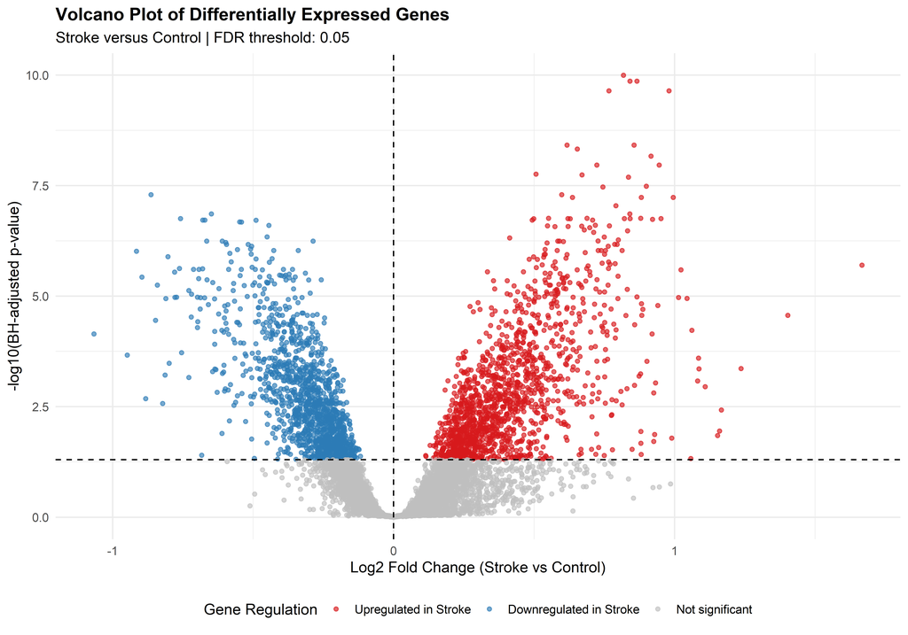

```r
# Prepare data for volcano plot
volcano_data <- deg_results

# Calculate negative log10 of adjusted p-values
# A small lower limit prevents infinite values when p-values are zero
volcano_data$neg_log10_FDR <- -log10(
  pmax(
    volcano_data$adj.P.Val,
    .Machine$double.xmin
  )
)

# Set the order of regulation categories
volcano_data$Regulation <- factor(
  volcano_data$Regulation,
  levels = c(
    "Upregulated in Stroke",
    "Downregulated in Stroke",
    "Not significant",
    "Significant (zero logFC)"
  )
)

# Create volcano plot
volcano_plot <- ggplot2::ggplot(
  volcano_data,
  ggplot2::aes(
    x = logFC,
    y = neg_log10_FDR,
    colour = Regulation
  )
) +

  # Display genes as points
  ggplot2::geom_point(
    alpha = 0.65,
    size = 1.3
  ) +

  # Add horizontal FDR significance threshold
  ggplot2::geom_hline(
    yintercept = -log10(fdr_threshold),
    linetype = "dashed",
    colour = "black"
  ) +

  # Add vertical reference line at zero log fold change
  ggplot2::geom_vline(
    xintercept = 0,
    linetype = "dashed",
    colour = "black"
  ) +

  # Define colours for regulation categories
  ggplot2::scale_colour_manual(
    values = c(
      "Upregulated in Stroke" = "#D7191C",
      "Downregulated in Stroke" = "#2C7BB6",
      "Not significant" = "grey75",
      "Significant (zero logFC)" = "#984EA3"
    ),
    drop = TRUE
  ) +

  # Add plot titles and labels
  ggplot2::labs(
    title = "Volcano Plot of Differentially Expressed Genes",
    subtitle = paste(
      "Stroke versus Control | FDR threshold:",
      fdr_threshold
    ),
    x = "Log2 Fold Change (Stroke vs Control)",
    y = "-log10(BH-adjusted p-value)",
    colour = "Gene Regulation"
  ) +

  # Apply plot formatting
  ggplot2::theme_minimal(base_size = 12) +

  ggplot2::theme(
    plot.title = ggplot2::element_text(
      face = "bold",
      size = 14
    ),

    legend.position = "bottom",

    # White background for the complete plot
    plot.background = ggplot2::element_rect(
      fill = "white",
      colour = NA
    ),

    # White background for the plotting panel
    panel.background = ggplot2::element_rect(
      fill = "white",
      colour = NA
    )
  )

# Define volcano plot output file
volcano_plot_file <- file.path(
  figure_dir,
  "fig5_volcano_plot.png"
)

# Save volcano plot with a white background
ggplot2::ggsave(
  filename = volcano_plot_file,
  plot = volcano_plot,
  width = 10,
  height = 7,
  dpi = 300,
  bg = "white"
)

# Verify volcano plot data and output
stopifnot(
  nrow(volcano_data) == nrow(deg_results),
  all(is.finite(volcano_data$neg_log10_FDR)),
  file.exists(volcano_plot_file),
  file.info(volcano_plot_file)$size > 0
)

# Display plot in the report
print(volcano_plot)
```

```r
cat("\nVolcano plot generated successfully.\n")
```

```
##
## Volcano plot generated successfully.
```

```r
cat(
  "Total genes displayed:",
  nrow(volcano_data),
  "\n"
)
```

```
## Total genes displayed: 17494
```

```r
cat(
  "Significant genes:",
  sum(volcano_data$adj.P.Val < fdr_threshold),
  "\n"
)
```

```
## Significant genes: 2779
```

```r
cat(
  "Upregulated genes:",
  nrow(upregulated_degs),
  "\n"
)
```

```
## Upregulated genes: 1443
```

```r
cat(
  "Downregulated genes:",
  nrow(downregulated_degs),
  "\n"
)
```

```
## Downregulated genes: 1336
```

## 5.5 Gene ID Annotation and Enrichment Background Preparation

Gene identifier mapping is performed to convert the gene symbols obtained from the GPL6883 platform annotation into Entrez Gene IDs using the human gene annotation database.

Entrez Gene IDs are used to connect the differentially expressed genes with biological functions and pathways during functional enrichment analysis.

The significant differentially expressed genes are mapped separately from the complete set of tested genes. All genes with a unique Entrez Gene ID mapping are retained as the background gene set for subsequent enrichment analysis.

```r
# Install Bioconductor packages if they are missing
annotation_packages <- c(
  "AnnotationDbi",
  "org.Hs.eg.db"
)

for (pkg in annotation_packages) {

  if (!requireNamespace(pkg, quietly = TRUE)) {

    BiocManager::install(
      pkg,
      ask = FALSE,
      update = FALSE
    )

  }

}

# Load human gene annotation database
library(AnnotationDbi)
library(org.Hs.eg.db)

# Retrieve unique gene symbols from all tested genes
gene_symbols <- unique(
  as.character(deg_results$Gene_Symbol)
)

# Verify gene symbols
stopifnot(
  length(gene_symbols) > 0,
  !anyNA(gene_symbols),
  all(nzchar(gene_symbols))
)

cat("Total unique gene symbols:", length(gene_symbols), "\n")
```

```
## Total unique gene symbols: 17494
```

```r
# Retrieve Entrez IDs and official gene names
annotation_table <- AnnotationDbi::select(
  x = org.Hs.eg.db::org.Hs.eg.db,
  keys = gene_symbols,
  columns = c("ENTREZID", "GENENAME"),
  keytype = "SYMBOL"
)

# Remove duplicate annotation records
annotation_table <- unique(annotation_table)

# Create a mapping function
map_single_gene <- function(symbol) {

  # Find annotation records for the gene symbol
  gene_rows <- annotation_table[
    !is.na(annotation_table$SYMBOL) &
      annotation_table$SYMBOL == symbol,
    ,
    drop = FALSE
  ]

  # Extract unique valid Entrez IDs
  entrez_ids <- unique(
    as.character(gene_rows$ENTREZID)
  )

  entrez_ids <- entrez_ids[
    !is.na(entrez_ids) & nzchar(entrez_ids)
  ]

  # Extract official gene names
  gene_names <- unique(
    as.character(gene_rows$GENENAME)
  )

  gene_names <- gene_names[
    !is.na(gene_names) & nzchar(gene_names)
  ]

  # Handle genes without an Entrez ID
  if (length(entrez_ids) == 0) {

    return(
      data.frame(
        Gene_Symbol = symbol,
        Gene_Name = NA_character_,
        ENTREZID = NA_character_,
        Mapping_Status = "Unmapped",
        stringsAsFactors = FALSE
      )
    )

  }

  # Exclude ambiguous one-to-many mappings
  if (length(entrez_ids) > 1) {

    return(
      data.frame(
        Gene_Symbol = symbol,
        Gene_Name = NA_character_,
        ENTREZID = NA_character_,
        Mapping_Status = "Ambiguous",
        stringsAsFactors = FALSE
      )
    )

  }

  # Return uniquely mapped gene information
  data.frame(
    Gene_Symbol = symbol,
    Gene_Name = if (length(gene_names) == 1) {
      gene_names[1]
    } else {
      NA_character_
    },
    ENTREZID = entrez_ids[1],
    Mapping_Status = "Mapped",
    stringsAsFactors = FALSE
  )

}

# Map all tested gene symbols
mapping_results <- lapply(
  gene_symbols,
  map_single_gene
)

gene_id_mapping <- do.call(
  rbind,
  mapping_results
)

rownames(gene_id_mapping) <- NULL

# Verify gene identifier mapping
stopifnot(
  nrow(gene_id_mapping) == length(gene_symbols),
  !anyDuplicated(gene_id_mapping$Gene_Symbol),
  all(
    gene_id_mapping$Mapping_Status %in%
      c("Mapped", "Unmapped", "Ambiguous")
  )
)

# Add gene identifiers to the complete DEG results
mapping_index <- match(
  deg_results$Gene_Symbol,
  gene_id_mapping$Gene_Symbol
)

deg_annotated_results <- deg_results

deg_annotated_results$Gene_Name <-
  gene_id_mapping$Gene_Name[mapping_index]

deg_annotated_results$ENTREZID <-
  gene_id_mapping$ENTREZID[mapping_index]

deg_annotated_results$Mapping_Status <-
  gene_id_mapping$Mapping_Status[mapping_index]

# Prepare background gene set from all tested genes
background_entrez <- unique(
  na.omit(gene_id_mapping$ENTREZID)
)

background_entrez <- sort(
  as.character(background_entrez)
)

# Prepare significant Entrez gene identifiers
significant_entrez <- unique(
  na.omit(
    deg_annotated_results$ENTREZID[
      deg_annotated_results$adj.P.Val < fdr_threshold
    ]
  )
)

# Prepare upregulated Entrez gene identifiers
upregulated_entrez <- unique(
  na.omit(
    deg_annotated_results$ENTREZID[
      deg_annotated_results$Regulation ==
        "Upregulated in Stroke"
    ]
  )
)

# Prepare downregulated Entrez gene identifiers
downregulated_entrez <- unique(
  na.omit(
    deg_annotated_results$ENTREZID[
      deg_annotated_results$Regulation ==
        "Downregulated in Stroke"
    ]
  )
)

# Check the enrichment gene sets
if (length(background_entrez) == 0) {
  stop("No genes were successfully mapped to Entrez IDs.")
}

if (length(significant_entrez) == 0) {
  stop("No significant DEGs have valid Entrez IDs.")
}

stopifnot(
  !anyDuplicated(background_entrez),
  !anyDuplicated(significant_entrez),
  all(significant_entrez %in% background_entrez),
  all(upregulated_entrez %in% background_entrez),
  all(downregulated_entrez %in% background_entrez)
)

# Store gene sets for subsequent enrichment analysis
enrichment_gene_sets <- list(
  significant = significant_entrez,
  upregulated = upregulated_entrez,
  downregulated = downregulated_entrez,
  universe = background_entrez
)

# Create an enrichment gene-set table
enrichment_gene_sets_table <- deg_annotated_results[
  ,
  c(
    "Gene_Symbol",
    "Gene_Name",
    "ENTREZID",
    "Regulation",
    "adj.P.Val",
    "Mapping_Status"
  )
]

enrichment_gene_sets_table$In_Enrichment_Background <-
  !is.na(enrichment_gene_sets_table$ENTREZID)

enrichment_gene_sets_table$In_Significant_DEG_Set <-
  enrichment_gene_sets_table$Regulation != "Not significant" &
  enrichment_gene_sets_table$Mapping_Status == "Mapped"

# Display mapping summary
cat("\nGene ID Mapping Summary\n")
```

```
##
## Gene ID Mapping Summary
```

```r
cat("-----------------------\n")
cat(
  "Total genes tested:",
  nrow(gene_id_mapping), "\n"
)
```

```
## Total genes tested: 17494
```

```r
cat(
  "Successfully mapped genes:",
  sum(gene_id_mapping$Mapping_Status == "Mapped"), "\n"
)
```

```
## Successfully mapped genes: 16679
```

```r
cat(
  "Unmapped genes:",
  sum(gene_id_mapping$Mapping_Status == "Unmapped"), "\n"
)
```

```
## Unmapped genes: 812
```

```r
cat(
  "Ambiguous mappings:",
  sum(gene_id_mapping$Mapping_Status == "Ambiguous"), "\n"
)
```

```
## Ambiguous mappings: 3
```

```r
cat(
  "Unique Entrez IDs in background:",
  length(background_entrez), "\n"
)
```

```
## Unique Entrez IDs in background: 16679
```

```r
cat(
  "Significant DEGs with Entrez IDs:",
  length(significant_entrez), "\n"
)
```

```
## Significant DEGs with Entrez IDs: 2640
```

```r
cat(
  "Upregulated genes with Entrez IDs:",
  length(upregulated_entrez), "\n"
)
```

```
## Upregulated genes with Entrez IDs: 1373
```

```r
cat(
  "Downregulated genes with Entrez IDs:",
  length(downregulated_entrez), "\n"
)
```

```
## Downregulated genes with Entrez IDs: 1267
```

```r
# Create mapping summary table
mapping_summary <- data.frame(
  Metric = c(
    "Total genes tested",
    "Successfully mapped genes",
    "Unmapped genes",
    "Ambiguous mappings",
    "Unique Entrez IDs in background",
    "Significant DEGs with Entrez IDs",
    "Upregulated genes with Entrez IDs",
    "Downregulated genes with Entrez IDs"
  ),

  Value = as.character(c(
    nrow(gene_id_mapping),
    sum(gene_id_mapping$Mapping_Status == "Mapped"),
    sum(gene_id_mapping$Mapping_Status == "Unmapped"),
    sum(gene_id_mapping$Mapping_Status == "Ambiguous"),
    length(background_entrez),
    length(significant_entrez),
    length(upregulated_entrez),
    length(downregulated_entrez)
  )),

  stringsAsFactors = FALSE
)

# Export gene identifier mapping
write.csv(
  gene_id_mapping,
  file.path(
    data_dir,
    "GSE16561_gene_id_mapping.csv"
  ),
  row.names = FALSE
)

# Export annotated differential expression results
write.csv(
  deg_annotated_results,
  file.path(
    data_dir,
    "GSE16561_annotated_DEG_results.csv"
  ),
  row.names = FALSE
)

# Export enrichment gene-set information
write.csv(
  enrichment_gene_sets_table,
  file.path(
    data_dir,
    "GSE16561_enrichment_gene_sets.csv"
  ),
  row.names = FALSE
)

# Export mapping summary
write.csv(
  mapping_summary,
  file.path(
    data_dir,
    "GSE16561_enrichment_mapping_summary.csv"
  ),
  row.names = FALSE
)

# Save gene sets for subsequent analysis
saveRDS(
  enrichment_gene_sets,
  file.path(
    data_dir,
    "GSE16561_enrichment_gene_sets.rds"
  )
)

# Verify all output files
mapping_output_files <- c(
  file.path(data_dir, "GSE16561_gene_id_mapping.csv"),
  file.path(data_dir, "GSE16561_annotated_DEG_results.csv"),
  file.path(data_dir, "GSE16561_enrichment_gene_sets.csv"),
  file.path(data_dir, "GSE16561_enrichment_mapping_summary.csv"),
  file.path(data_dir, "GSE16561_enrichment_gene_sets.rds")
)

stopifnot(
  all(file.exists(mapping_output_files)),
  all(file.info(mapping_output_files)$size > 0)
)

cat("\nAll gene annotation output files verified.\n")
```

```
##
## All gene annotation output files verified.
```

```r
cat("\nGene ID annotation completed successfully.\n")
```

```
##
## Gene ID annotation completed successfully.
```

# 5.6 Functional and Pathway Enrichment Analysis

Functional enrichment analysis is performed to investigate the biological processes, molecular functions, cellular components and pathways associated with differentially expressed genes in acute ischemic stroke.

Gene Ontology (GO) enrichment is performed for Biological Process (BP), Molecular Function (MF) and Cellular Component (CC). Biological Process enrichment is also performed separately for upregulated and downregulated genes.

KEGG pathway enrichment is performed for all significant genes and for the upregulated and downregulated gene sets separately.

The analysis uses Entrez Gene IDs and the mapped background gene set prepared in Section 5.5. Benjamini-Hochberg adjustment is used to control the false discovery rate.

```r
# Check required packages
stopifnot(
  requireNamespace("limma", quietly = TRUE),
  requireNamespace("org.Hs.eg.db", quietly = TRUE),
  requireNamespace("ggplot2", quietly = TRUE)
)

# Verify gene sets from Section 5.5
stopifnot(
  exists("background_entrez"),
  exists("significant_entrez"),
  exists("upregulated_entrez"),
  exists("downregulated_entrez")
)

# Prepare unique Entrez gene IDs
background_entrez <- unique(na.omit(as.character(background_entrez)))
significant_entrez <- unique(na.omit(as.character(significant_entrez)))
upregulated_entrez <- unique(na.omit(as.character(upregulated_entrez)))
downregulated_entrez <- unique(na.omit(as.character(downregulated_entrez)))

# Verify gene sets
stopifnot(
  length(background_entrez) > 0,
  length(significant_entrez) > 0,
  all(significant_entrez %in% background_entrez),
  all(upregulated_entrez %in% background_entrez),
  all(downregulated_entrez %in% background_entrez)
)

# Set FDR threshold
enrichment_fdr_threshold <- 0.05

# Function to perform GO enrichment
run_go_enrichment <- function(gene_ids, analysis_name) {

  result <- limma::goana(
    de = gene_ids,
    universe = background_entrez,
    species = "Hs"
  )

  result <- as.data.frame(result)

  if (nrow(result) == 0) {
    return(result)
  }

  # Preserve GO identifiers
  result$GO_ID <- rownames(result)

  result$Analysis <- analysis_name

  result$Input_Genes <- length(gene_ids)

  # Adjust p-values separately for each GO ontology
  result$FDR <- NA_real_

  for (ontology in unique(result$Ont)) {

    selected <- result$Ont == ontology

    result$FDR[selected] <- p.adjust(
      result$P.DE[selected],
      method = "BH"
    )

  }

  result$Significant <- (
    !is.na(result$FDR) &
      result$FDR < enrichment_fdr_threshold
  )

  rownames(result) <- NULL

  result
}

# Perform GO analysis for all significant genes
go_all <- run_go_enrichment(
  significant_entrez,
  "All significant DEGs"
)

# Perform GO analysis for upregulated genes
go_up <- run_go_enrichment(
  upregulated_entrez,
  "Upregulated genes"
)

# Perform GO analysis for downregulated genes
go_down <- run_go_enrichment(
  downregulated_entrez,
  "Downregulated genes"
)

# Separate GO ontologies
go_bp_all <- subset(go_all, Ont == "BP")
go_mf_all <- subset(go_all, Ont == "MF")
go_cc_all <- subset(go_all, Ont == "CC")

go_bp_upregulated <- subset(go_up, Ont == "BP")
go_bp_downregulated <- subset(go_down, Ont == "BP")

cat("\nGO enrichment analysis completed.\n")
```

```
##
## GO enrichment analysis completed.
```

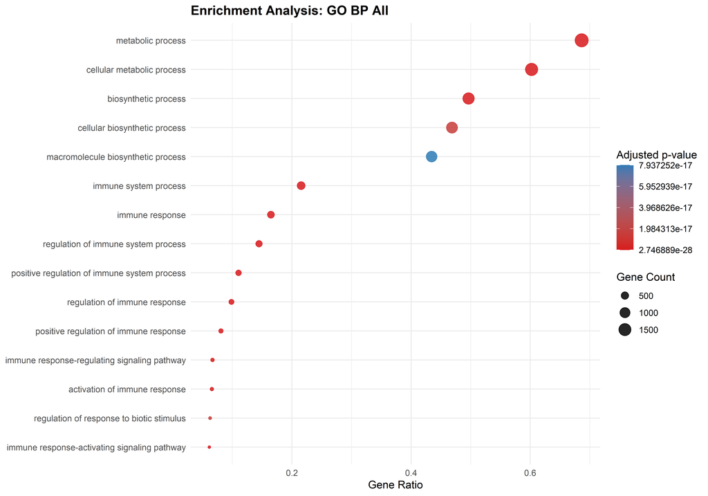

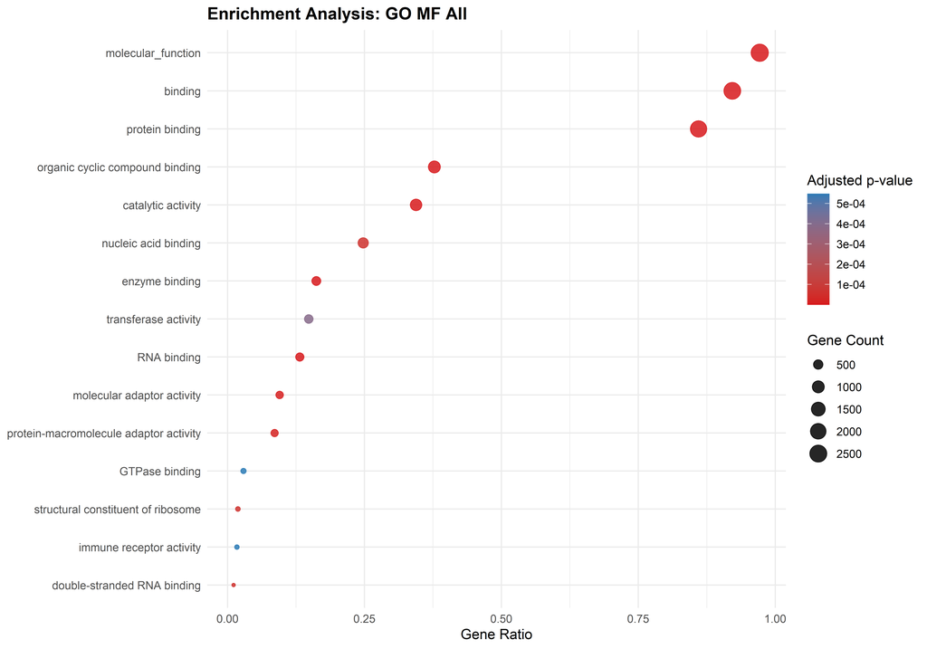

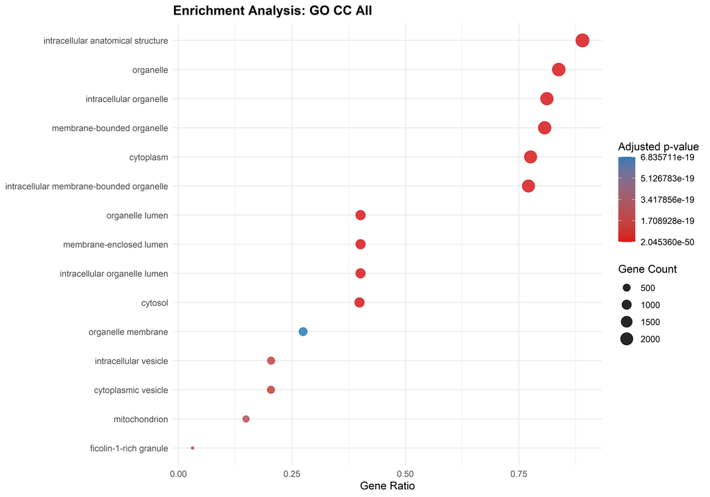

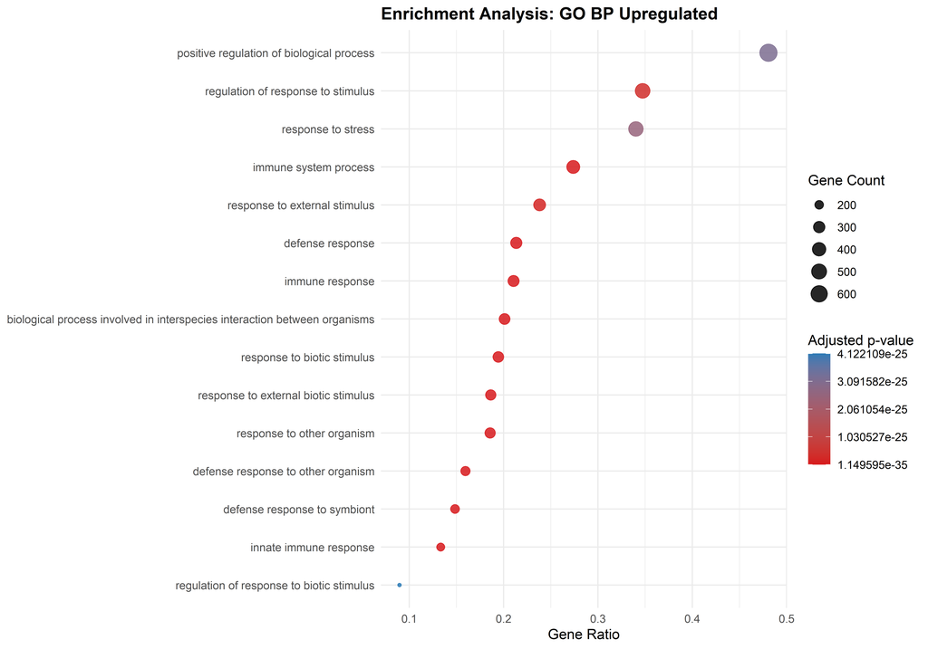

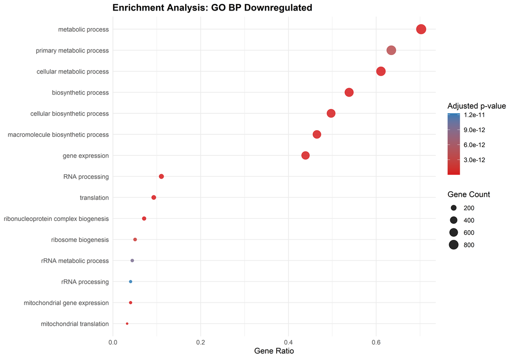

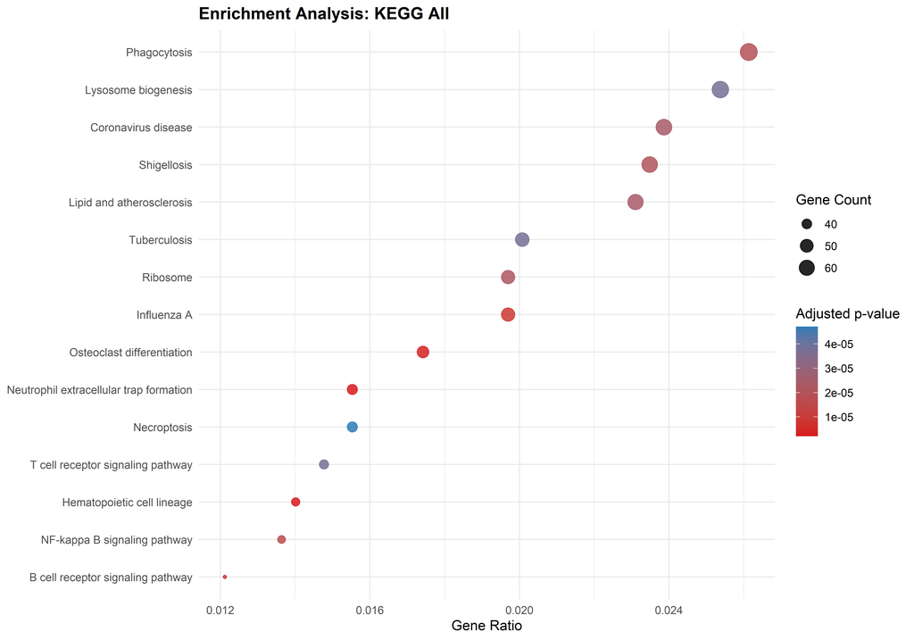

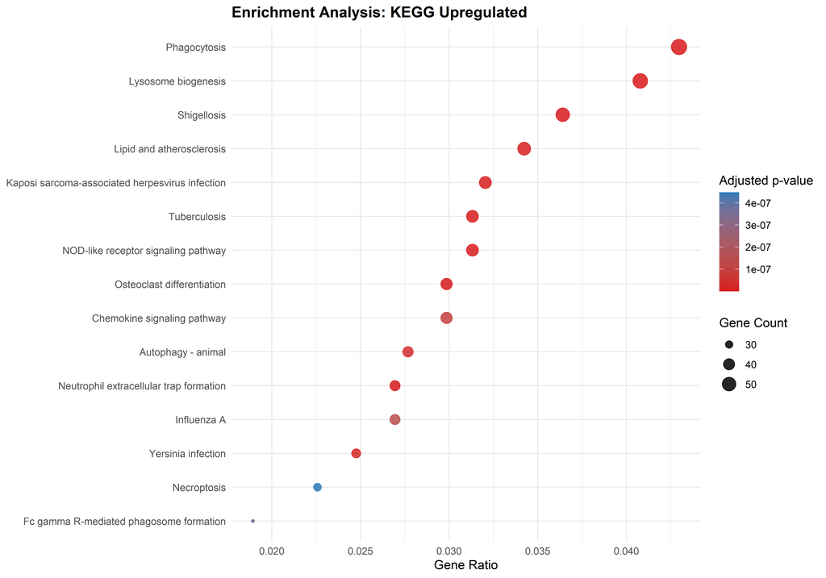

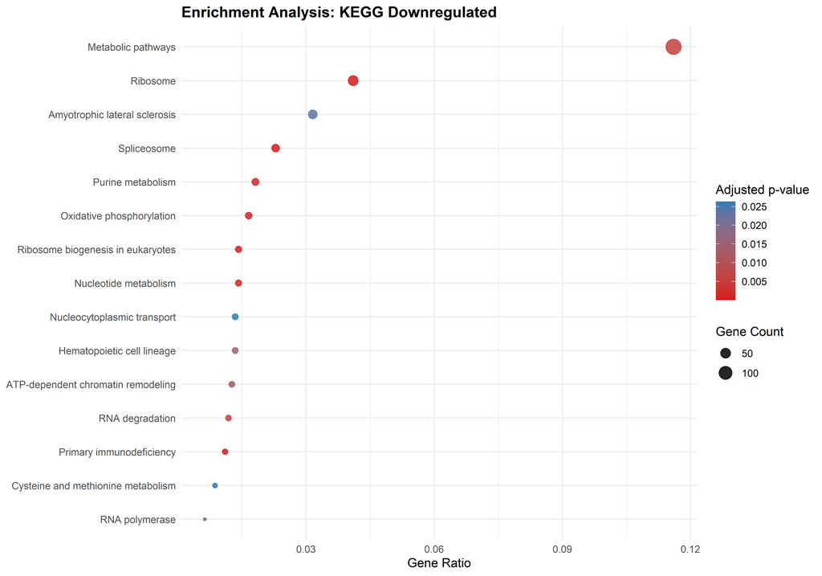

```r
# Function to perform KEGG enrichment
run_kegg_enrichment <- function(gene_ids, analysis_name) {

  tryCatch({

    result <- limma::kegga(
      de = gene_ids,
      universe = background_entrez,
      species.KEGG = "hsa"
    )

    result <- as.data.frame(result)

    if (nrow(result) > 0) {

      result$KEGG_ID <- rownames(result)

      # Standardise pathway description column
      result$Term <- result$Pathway

      result$Analysis <- analysis_name

      result$Input_Genes <- length(gene_ids)

      result$FDR <- p.adjust(
        result$P.DE,
        method = "BH"
      )

      result$Significant <- (
        !is.na(result$FDR) &
          result$FDR < enrichment_fdr_threshold
      )

      rownames(result) <- NULL

    }

    list(
      table = result,
      status = "Completed"
    )

  }, error = function(e) {

    cat(
      "\nKEGG analysis unavailable for",
      analysis_name,
      ":",
      conditionMessage(e),
      "\n"
    )

    list(
      table = data.frame(),
      status = paste(
        "Unavailable:",
        conditionMessage(e)
      )
    )

  })

}

# Perform KEGG enrichment analyses
kegg_all_result <- run_kegg_enrichment(
  significant_entrez,
  "All significant DEGs"
)

kegg_up_result <- run_kegg_enrichment(
  upregulated_entrez,
  "Upregulated genes"
)

kegg_down_result <- run_kegg_enrichment(
  downregulated_entrez,
  "Downregulated genes"
)

# Collect enrichment tables
enrichment_results <- list(

  GO_BP_All = go_bp_all,

  GO_MF_All = go_mf_all,

  GO_CC_All = go_cc_all,

  GO_BP_Upregulated = go_bp_upregulated,

  GO_BP_Downregulated = go_bp_downregulated,

  KEGG_All = kegg_all_result$table,

  KEGG_Upregulated = kegg_up_result$table,

  KEGG_Downregulated = kegg_down_result$table

)

# Record KEGG analysis statuses
kegg_status <- c(
  KEGG_All = kegg_all_result$status,
  KEGG_Upregulated = kegg_up_result$status,
  KEGG_Downregulated = kegg_down_result$status
)

# Define output CSV filenames
enrichment_csv_files <- setNames(

  file.path(
    data_dir,
    paste0(
      "GSE16561_",
      tolower(names(enrichment_results)),
      "_enrichment.csv"
    )
  ),

  names(enrichment_results)

)

# Export enrichment tables
for (result_name in names(enrichment_results)) {

  result_table <- enrichment_results[[result_name]]

  if (ncol(result_table) == 0) {

    result_table <- data.frame(
      Note = "No results were returned. Check the analysis status."
    )

  }

  write.csv(
    result_table,
    enrichment_csv_files[[result_name]],
    row.names = FALSE
  )

}

# Create enrichment summary
enrichment_summary <- do.call(

  rbind,

  lapply(
    names(enrichment_results),

    function(result_name) {

      result_table <- enrichment_results[[result_name]]

      returned_terms <- nrow(result_table)

      significant_terms <- if (
        returned_terms > 0 &&
        "FDR" %in% names(result_table)
      ) {

        sum(
          !is.na(result_table$FDR) &
            result_table$FDR < enrichment_fdr_threshold
        )

      } else {
        0
      }

      status <- if (
        grepl("^KEGG", result_name)
      ) {

        unname(kegg_status[result_name])

      } else {

        "Completed"

      }

      data.frame(

        Analysis = result_name,

        Returned_Terms = returned_terms,

        Significant_Terms_FDR_0.05 = significant_terms,

        Status = status,

        stringsAsFactors = FALSE

      )

    }

  )

)

# Export summary
enrichment_summary_file <- file.path(
  data_dir,
  "GSE16561_enrichment_summary.csv"
)

write.csv(
  enrichment_summary,
  enrichment_summary_file,
  row.names = FALSE
)

# Function to generate enrichment dot plots
create_enrichment_plot <- function(
  result_table,
  plot_title,
  output_file
) {

  significant_terms <- data.frame()

  if (
    nrow(result_table) > 0 &&
    all(c("FDR", "Term", "DE", "Input_Genes") %in%
        names(result_table))
  ) {

    significant_terms <- result_table[
      !is.na(result_table$FDR) &
        result_table$FDR < enrichment_fdr_threshold,
      ,
      drop = FALSE
    ]

  }

  # Create plot when significant terms are available
  if (nrow(significant_terms) > 0) {

    significant_terms$GeneRatio <- (
      significant_terms$DE /
        significant_terms$Input_Genes
    )

    significant_terms <- significant_terms[
      order(significant_terms$FDR),
      ,
      drop = FALSE
    ]

    significant_terms <- head(
      significant_terms,
      15
    )

    enrichment_plot <- ggplot2::ggplot(

      significant_terms,

      ggplot2::aes(
        x = GeneRatio,
        y = reorder(Term, GeneRatio)
      )

    ) +

      ggplot2::geom_point(

        ggplot2::aes(
          size = DE,
          color = FDR
        ),

        alpha = 0.85

      ) +

      ggplot2::scale_color_gradient(
        low = "#D7191C",
        high = "#2C7BB6"
      ) +

      ggplot2::labs(
        title = plot_title,
        x = "Gene Ratio",
        y = NULL,
        color = "Adjusted p-value",
        size = "Gene Count"
      ) +

      ggplot2::theme_minimal(base_size = 11) +

      ggplot2::theme(
        plot.title = ggplot2::element_text(
          face = "bold"
        ),
        plot.background = ggplot2::element_rect(
          fill = "white",
          colour = NA
        ),
        panel.background = ggplot2::element_rect(
          fill = "white",
          colour = NA
        )
      )

  } else {

    # Display a message when no terms pass the FDR threshold
    enrichment_plot <- ggplot2::ggplot() +

      ggplot2::annotate(
        "text",
        x = 0,
        y = 0,
        label = "No significantly enriched terms (FDR < 0.05)."
      ) +

      ggplot2::xlim(-1, 1) +

      ggplot2::ylim(-1, 1) +

      ggplot2::labs(title = plot_title) +

      ggplot2::theme_void() +

      ggplot2::theme(
        plot.title = ggplot2::element_text(
          face = "bold",
          hjust = 0.5
        ),
        plot.background = ggplot2::element_rect(
          fill = "white",
          colour = NA
        )
      )

  }

  # Save plot
  ggplot2::ggsave(
    filename = output_file,
    plot = enrichment_plot,
    width = 10,
    height = 7,
    dpi = 300,
    bg = "white"
  )

  enrichment_plot

}

# Define output figure files
enrichment_plot_files <- c(

  GO_BP_All = file.path(
    figure_dir,
    "fig6_GO_BP_all_DEGs.png"
  ),

  GO_MF_All = file.path(
    figure_dir,
    "fig7_GO_MF_all_DEGs.png"
  ),

  GO_CC_All = file.path(
    figure_dir,
    "fig8_GO_CC_all_DEGs.png"
  ),

  GO_BP_Upregulated = file.path(
    figure_dir,
    "fig9_GO_BP_upregulated_DEGs.png"
  ),

  GO_BP_Downregulated = file.path(
    figure_dir,
    "fig10_GO_BP_downregulated_DEGs.png"
  ),

  KEGG_All = file.path(
    figure_dir,
    "fig11_KEGG_all_DEGs.png"
  ),

  KEGG_Upregulated = file.path(
    figure_dir,
    "fig12_KEGG_upregulated_DEGs.png"
  ),

  KEGG_Downregulated = file.path(
    figure_dir,
    "fig13_KEGG_downregulated_DEGs.png"
  )

)

# Generate enrichment figures
enrichment_plots <- list()

for (result_name in names(enrichment_plot_files)) {

  enrichment_plots[[result_name]] <- create_enrichment_plot(

    result_table = enrichment_results[[result_name]],

    plot_title = paste(
      "Enrichment Analysis:",
      gsub("_", " ", result_name)
    ),

    output_file = enrichment_plot_files[[result_name]]

  )

  print(enrichment_plots[[result_name]])

}
```

```r
# Save results for reproducibility
enrichment_rds_file <- file.path(
  data_dir,
  "GSE16561_functional_enrichment_results.rds"
)

saveRDS(
  enrichment_results,
  enrichment_rds_file
)

# Verify all output files
enrichment_required_files <- c(

  enrichment_csv_files,

  enrichment_summary_file,

  enrichment_plot_files,

  enrichment_rds_file

)

stopifnot(
  all(file.exists(enrichment_required_files)),
  all(file.info(enrichment_required_files)$size > 0)
)

# Display summary
cat("\nFunctional Enrichment Summary\n")
```

```
##
## Functional Enrichment Summary
```

```r
cat("-----------------------------\n")
print(
  enrichment_summary,
  row.names = FALSE
)
```

```
##             Analysis Returned_Terms Significant_Terms_FDR_0.05    Status
##            GO_BP_All          15196                        675 Completed
##            GO_MF_All           4929                         51 Completed
##            GO_CC_All           1970                        142 Completed
##    GO_BP_Upregulated          15196                        995 Completed
##  GO_BP_Downregulated          15196                        176 Completed
##             KEGG_All            373                         81 Completed
##     KEGG_Upregulated            373                        117 Completed
##   KEGG_Downregulated            373                         17 Completed
```

```r
cat("\nMapped background genes:", length(background_entrez), "\n")
```

```
##
## Mapped background genes: 16679
```

```r
cat("Significant genes analysed:", length(significant_entrez), "\n")
```

```
## Significant genes analysed: 2640
```

```r
cat("Upregulated genes analysed:", length(upregulated_entrez), "\n")
```

```
## Upregulated genes analysed: 1373
```

```r
cat("Downregulated genes analysed:", length(downregulated_entrez), "\n")
```

```
## Downregulated genes analysed: 1267
```

```r
cat("\nAll enrichment output files verified.\n")
```

```
##
## All enrichment output files verified.
```

# 5.7 Machine Learning Model Development

Machine learning is used to investigate whether gene expression profiles can distinguish acute ischemic stroke samples from healthy control samples.

Three supervised classification algorithms are compared:

1. Elastic Net Logistic Regression
2. Support Vector Machine (SVM) with a radial basis function kernel
3. Random Forest

Because the dataset contains many genes but only 63 samples, a nested cross-validation strategy is used. Gene selection and model tuning are performed only within the training data to reduce information leakage.

The outer validation uses repeated stratified five-fold cross-validation. Three-fold stratified cross-validation within each outer training set is used to select model parameters.

The out-of-fold predictions, tuning results and selected genes are saved for subsequent model evaluation.

```r
# Verify required packages
ml_packages <- c(
  "glmnet",
  "e1071",
  "randomForest",
  "limma"
)

ml_package_status <- vapply(
  ml_packages,
  requireNamespace,
  quietly = TRUE,
  FUN.VALUE = logical(1)
)

if (!all(ml_package_status)) {
  stop("One or more required machine learning packages are missing.")
}

# Verify expression matrix and clinical metadata
stopifnot(
  is.matrix(expr_gene),
  is.numeric(expr_gene),
  ncol(expr_gene) == 63,
  nrow(metadata) == 63,
  identical(colnames(expr_gene), metadata$Sample_ID),
  !anyNA(expr_gene),
  !anyNA(metadata$Group),
  sum(metadata$Group == "Control") == 24,
  sum(metadata$Group == "Stroke") == 39
)

# Set factor levels for classification
metadata$Group <- factor(
  metadata$Group,
  levels = c("Control", "Stroke")
)

# Machine learning settings
ml_seed <- 2026

number_outer_folds <- 5
number_outer_repeats <- 2
number_inner_folds <- 3

candidate_gene_counts <- c(10L, 20L)

# --------------------------------------------------
# Function 1: Create stratified cross-validation folds
# --------------------------------------------------

make_stratified_folds <- function(group, k, seed) {

  group <- factor(
    group,
    levels = c("Control", "Stroke")
  )

  if (any(table(group) < k)) {
    stop("Each class must contain at least k samples.")
  }

  set.seed(seed)

  fold_assignment <- integer(length(group))

  for (class_name in levels(group)) {

    class_indices <- which(group == class_name)

    fold_assignment[class_indices] <- sample(
      rep(
        seq_len(k),
        length.out = length(class_indices)
      )
    )

  }

  lapply(
    seq_len(k),
    function(fold_number) {
      which(fold_assignment == fold_number)
    }
  )

}

# --------------------------------------------------
# Function 2: Calculate ROC-AUC
# --------------------------------------------------

calculate_auc <- function(actual, predicted_probability) {

  actual <- as.character(actual)

  positive <- actual == "Stroke"

  n_positive <- sum(positive)
  n_negative <- sum(!positive)

  if (
    n_positive == 0 ||
    n_negative == 0 ||
    any(!is.finite(predicted_probability))
  ) {
    return(NA_real_)
  }

  probability_ranks <- rank(
    predicted_probability,
    ties.method = "average"
  )

  auc_value <- (
    sum(probability_ranks[positive]) -
      n_positive * (n_positive + 1) / 2
  ) / (n_positive * n_negative)

  as.numeric(auc_value)

}

# --------------------------------------------------
# Function 3: Select genes using training data only
# --------------------------------------------------

select_top_genes <- function(sample_indices) {

  training_metadata <- metadata[
    sample_indices,
    ,
    drop = FALSE
  ]

  training_expression <- expr_gene[
    ,
    sample_indices,
    drop = FALSE
  ]

  # Create design matrix using training samples only
  training_design <- model.matrix(
    ~ Group,
    data = training_metadata
  )

  # Fit Limma model using training samples only
  training_fit <- limma::lmFit(
    training_expression,
    training_design
  )

  training_fit <- limma::eBayes(
    training_fit,
    robust = TRUE
  )

  # Rank genes by differential expression p-value
  ranked_results <- limma::topTable(
    training_fit,
    coef = "GroupStroke",
    number = 20,
    adjust.method = "BH",
    sort.by = "P"
  )

  selected_genes <- rownames(ranked_results)

  if (
    length(selected_genes) < max(candidate_gene_counts)
  ) {
    stop("Insufficient genes available for feature selection.")
  }

  selected_genes

}

# --------------------------------------------------
# Function 4: Fit classifier and obtain probabilities
# --------------------------------------------------

predict_classifier_probability <- function(
  model_name,
  training_x,
  training_y,
  validation_x,
  parameters
) {

  training_y <- factor(
    as.character(training_y),
    levels = c("Control", "Stroke")
  )

  validation_x <- as.matrix(validation_x)
  training_x <- as.matrix(training_x)

  # Elastic Net Logistic Regression
  if (model_name == "Elastic Net") {

    fitted_model <- glmnet::glmnet(

      x = training_x,

      y = as.integer(training_y == "Stroke"),

      family = "binomial",

      alpha = parameters$alpha,

      lambda = parameters$lambda,

      standardize = TRUE

    )

    predicted_probability <- predict(

      fitted_model,

      newx = validation_x,

      s = parameters$lambda,

      type = "response"

    )

    return(as.numeric(predicted_probability[, 1]))

  }

  # Scale data using training data only
  training_center <- colMeans(training_x)

  training_scale <- apply(
    training_x,
    2,
    sd
  )

  training_scale[
    !is.finite(training_scale) |
      training_scale == 0
  ] <- 1

  scaled_training_x <- scale(
    training_x,
    center = training_center,
    scale = training_scale
  )

  scaled_validation_x <- scale(
    validation_x,
    center = training_center,
    scale = training_scale
  )

  # Support Vector Machine
  if (model_name == "SVM") {

    fitted_model <- e1071::svm(

      x = scaled_training_x,

      y = training_y,

      kernel = "radial",

      cost = parameters$cost,

      gamma = parameters$gamma,

      probability = TRUE,

      scale = FALSE

    )

    svm_prediction <- predict(

      fitted_model,

      newdata = scaled_validation_x,

      probability = TRUE

    )

    svm_probabilities <- attr(
      svm_prediction,
      "probabilities"
    )

    if (
      is.null(svm_probabilities) ||
      !"Stroke" %in% colnames(svm_probabilities)
    ) {
      stop("SVM probability predictions are unavailable.")
    }

    return(
      as.numeric(svm_probabilities[, "Stroke"])
    )

  }

  # Random Forest
  if (model_name == "Random Forest") {

    selected_mtry <- max(
      1,
      min(
        ncol(training_x),
        round(
          ncol(training_x) *
            parameters$mtry_fraction
        )
      )
    )

    fitted_model <- randomForest::randomForest(

      x = training_x,

      y = training_y,
```

```r
      ntree = 300,

      mtry = selected_mtry,

      nodesize = parameters$nodesize,

      importance = FALSE

    )

    rf_probabilities <- predict(

      fitted_model,

      newdata = validation_x,

      type = "prob"

    )

    return(
      as.numeric(rf_probabilities[, "Stroke"])
    )

  }

  stop("Unknown machine learning model.")

}

# --------------------------------------------------
# Function 5: Tune model using inner cross-validation
# --------------------------------------------------

tune_classifier <- function(
  model_name,
  parameter_grid,
  inner_cache,
  seed_base
) {

  candidate_results <- vector(
    "list",
    nrow(parameter_grid)
  )

  for (candidate in seq_len(nrow(parameter_grid))) {

    parameters <- as.list(
      parameter_grid[candidate, , drop = FALSE]
    )

    inner_auc <- rep(
      NA_real_,
      length(inner_cache)
    )

    for (fold_index in seq_along(inner_cache)) {

      fold_data <- inner_cache[[fold_index]]

      selected_genes <- fold_data$ranked_genes[
        seq_len(parameters$n_features)
      ]

      training_x <- t(
        expr_gene[
          selected_genes,
          fold_data$training_indices,
          drop = FALSE
        ]
      )

      validation_x <- t(
        expr_gene[
          selected_genes,
          fold_data$validation_indices,
          drop = FALSE
        ]
      )

      training_y <- metadata$Group[
        fold_data$training_indices
      ]

      validation_y <- metadata$Group[
        fold_data$validation_indices
      ]

      # Fit and predict within this inner fold
      inner_auc[fold_index] <- tryCatch({

        set.seed(
          seed_base +
            candidate * 100 +
            fold_index
        )

        probability <- predict_classifier_probability(

          model_name = model_name,

          training_x = training_x,

          training_y = training_y,

          validation_x = validation_x,

          parameters = parameters

        )

        calculate_auc(
          validation_y,
          probability
        )

      }, error = function(e) {

        NA_real_

      })

    }

    # Require successful results from every inner fold
    mean_auc <- if (all(is.finite(inner_auc))) {
      mean(inner_auc)
    } else {
      NA_real_
    }

    sd_auc <- if (all(is.finite(inner_auc))) {
      sd(inner_auc)
    } else {
      NA_real_
    }

    candidate_results[[candidate]] <- data.frame(

      Model = model_name,

      parameter_grid[candidate, , drop = FALSE],

      Mean_Inner_AUC = mean_auc,

      SD_Inner_AUC = sd_auc,

      Successful_Inner_Folds = sum(
        is.finite(inner_auc)
      ),

      stringsAsFactors = FALSE

    )

  }

  tuning_scores <- do.call(
    rbind,
    candidate_results
  )

  valid_candidates <- which(
    is.finite(tuning_scores$Mean_Inner_AUC)
  )

  if (length(valid_candidates) == 0) {
    stop(
      paste(
        "No valid tuning configuration for",
        model_name
      )
    )
  }

  # Select the configuration with the highest mean inner AUC
  best_index <- valid_candidates[
    which.max(
      tuning_scores$Mean_Inner_AUC[valid_candidates]
    )
  ]

  best_parameters <- as.list(
    tuning_scores[
      best_index,
      names(parameter_grid),
      drop = FALSE
    ]
  )

  list(

    best_parameters = best_parameters,

    best_inner_auc = tuning_scores$Mean_Inner_AUC[
      best_index
    ],

    tuning_scores = tuning_scores

  )

}

# --------------------------------------------------
# Define candidate parameter grids
# --------------------------------------------------

elastic_net_grid <- expand.grid(

  n_features = candidate_gene_counts,

  alpha = c(0.5, 1.0),

  lambda = c(0.001, 0.01, 0.1),

  KEEP.OUT.ATTRS = FALSE

)

svm_grid <- expand.grid(

  n_features = candidate_gene_counts,

  cost = c(0.1, 1, 10),

  gamma = c(0.01, 0.1),

  KEEP.OUT.ATTRS = FALSE

)

random_forest_grid <- expand.grid(

  n_features = candidate_gene_counts,

  mtry_fraction = c(0.2, 0.5),

  nodesize = c(1, 3),

  KEEP.OUT.ATTRS = FALSE

)

# Store parameter grids
model_grids <- list(

  "Elastic Net" = elastic_net_grid,

  "SVM" = svm_grid,

  "Random Forest" = random_forest_grid

)

# --------------------------------------------------
# Nested repeated cross-validation
# --------------------------------------------------

outer_prediction_results <- list()

tuning_results_list <- list()

selected_features_list <- list()

prediction_index <- 1
tuning_index <- 1
feature_index <- 1

number_samples <- nrow(metadata)

for (repeat_id in seq_len(number_outer_repeats)) {

  cat(
    "\nOuter cross-validation repeat:",
    repeat_id,
    "\n"
  )

  # Create outer stratified folds
  outer_folds <- make_stratified_folds(

    group = metadata$Group,

    k = number_outer_folds,

    seed = ml_seed + repeat_id

  )

  for (outer_fold in seq_len(number_outer_folds)) {

    cat(
      "\nRepeat",
      repeat_id,
      "- Outer fold",
      outer_fold,
      "\n"
    )

    # Split outer training and validation samples
    outer_validation_indices <- outer_folds[[outer_fold]]

    outer_training_indices <- setdiff(
      seq_len(number_samples),
      outer_validation_indices
    )

    # Create inner stratified folds within outer training data
    inner_folds <- make_stratified_folds(

      group = metadata$Group[
        outer_training_indices
      ],

      k = number_inner_folds,

      seed = ml_seed +
        repeat_id * 100 +
        outer_fold

    )

    # Precalculate gene rankings using each inner training fold
    inner_cache <- lapply(

      seq_along(inner_folds),

      function(inner_fold) {

        inner_validation_local <- inner_folds[[inner_fold]]

        inner_training_local <- setdiff(

          seq_along(outer_training_indices),

          inner_validation_local

        )

        inner_training_indices <- outer_training_indices[
          inner_training_local
        ]

        inner_validation_indices <- outer_training_indices[
          inner_validation_local
        ]
```

```r
        list(

          training_indices = inner_training_indices,

          validation_indices = inner_validation_indices,

          ranked_genes = select_top_genes(
            inner_training_indices
          )

        )

      }

    )

    # Tune and evaluate each model
    for (model_name in names(model_grids)) {

      cat(
        "Tuning model:",
        model_name,
        "\n"
      )

      tuning_output <- tune_classifier(

        model_name = model_name,

        parameter_grid = model_grids[[model_name]],

        inner_cache = inner_cache,

        seed_base = ml_seed +
          repeat_id * 10000 +
          outer_fold * 1000

      )


# Save inner tuning scores using a common table structure
tuning_table <- tuning_output$tuning_scores

tuning_results_list[[tuning_index]] <- data.frame(

  Model = as.character(tuning_table$Model),

  Repeat = repeat_id,

  Outer_Fold = outer_fold,

  N_Features = as.integer(tuning_table$n_features),

  Alpha = if ("alpha" %in% names(tuning_table)) {
    as.numeric(tuning_table$alpha)
  } else {
    rep(NA_real_, nrow(tuning_table))
  },

  Lambda = if ("lambda" %in% names(tuning_table)) {
    as.numeric(tuning_table$lambda)
  } else {
    rep(NA_real_, nrow(tuning_table))
  },

  Cost = if ("cost" %in% names(tuning_table)) {
    as.numeric(tuning_table$cost)
  } else {
    rep(NA_real_, nrow(tuning_table))
  },

  Gamma = if ("gamma" %in% names(tuning_table)) {
    as.numeric(tuning_table$gamma)
  } else {
    rep(NA_real_, nrow(tuning_table))
  },

  Mtry_Fraction = if ("mtry_fraction" %in% names(tuning_table)) {
    as.numeric(tuning_table$mtry_fraction)
  } else {
    rep(NA_real_, nrow(tuning_table))
  },

  Nodesize = if ("nodesize" %in% names(tuning_table)) {
    as.numeric(tuning_table$nodesize)
  } else {
    rep(NA_real_, nrow(tuning_table))
  },

  Mean_Inner_AUC = as.numeric(
    tuning_table$Mean_Inner_AUC
  ),

  SD_Inner_AUC = as.numeric(
    tuning_table$SD_Inner_AUC
  ),

  Successful_Inner_Folds = as.integer(
    tuning_table$Successful_Inner_Folds
  ),

  stringsAsFactors = FALSE

)

tuning_index <- tuning_index + 1

      best_parameters <- tuning_output$best_parameters

      # Perform gene selection again using the complete outer training set
      outer_ranked_genes <- select_top_genes(
        outer_training_indices
      )

      final_genes <- outer_ranked_genes[
        seq_len(best_parameters$n_features)
      ]

      # Construct outer training and validation expression matrices
      outer_training_x <- t(

        expr_gene[
          final_genes,
          outer_training_indices,
          drop = FALSE
        ]

      )

      outer_validation_x <- t(

        expr_gene[
          final_genes,
          outer_validation_indices,
          drop = FALSE
        ]

      )

      outer_training_y <- metadata$Group[
        outer_training_indices
      ]

      outer_validation_y <- metadata$Group[
        outer_validation_indices
      ]

      # Fit the selected model and predict outer validation samples
      set.seed(

        ml_seed +
          repeat_id * 100000 +
          outer_fold * 1000 +
          match(model_name, names(model_grids))

      )

      outer_probabilities <- predict_classifier_probability(

        model_name = model_name,

        training_x = outer_training_x,

        training_y = outer_training_y,

        validation_x = outer_validation_x,

        parameters = best_parameters

      )

      if (
        length(outer_probabilities) !=
          length(outer_validation_indices) ||
        any(!is.finite(outer_probabilities))
      ) {

        stop(
          paste(
            "Invalid outer predictions generated by",
            model_name
          )
        )

      }

      # Save out-of-fold predictions
      outer_prediction_results[[prediction_index]] <- data.frame(

        Repeat = repeat_id,

        Outer_Fold = outer_fold,

        Sample_ID = metadata$Sample_ID[
          outer_validation_indices
        ],

        Actual = as.character(
          outer_validation_y
        ),

        Model = model_name,

        Probability_Stroke = as.numeric(
          outer_probabilities
        ),

        Predicted_Class = ifelse(
          outer_probabilities >= 0.5,
          "Stroke",
          "Control"
        ),

        stringsAsFactors = FALSE

      )

      prediction_index <- prediction_index + 1

      # Save selected genes for reproducibility
      selected_features_list[[feature_index]] <- data.frame(

        Repeat = repeat_id,

        Outer_Fold = outer_fold,

        Model = model_name,

        Feature_Rank = seq_along(final_genes),

        Gene_Symbol = final_genes,

        stringsAsFactors = FALSE

      )

      feature_index <- feature_index + 1

      cat(
        "Best inner AUC:",
        round(tuning_output$best_inner_auc, 4),
        "\n"
      )

    }

  }

}
```

```
##
## Outer cross-validation repeat: 1
##
## Repeat 1 - Outer fold 1
## Tuning model: Elastic Net
## Best inner AUC: 0.9889
## Tuning model: SVM
## Best inner AUC: 0.9889
## Tuning model: Random Forest
## Best inner AUC: 0.9889
##
## Repeat 1 - Outer fold 2
## Tuning model: Elastic Net
## Best inner AUC: 0.987
## Tuning model: SVM
## Best inner AUC: 0.9957
## Tuning model: Random Forest
## Best inner AUC: 0.9802
##
## Repeat 1 - Outer fold 3
## Tuning model: Elastic Net
## Best inner AUC: 0.9889
## Tuning model: SVM
## Best inner AUC: 0.9944
## Tuning model: Random Forest
## Best inner AUC: 0.9944
##
## Repeat 1 - Outer fold 4
## Tuning model: Elastic Net
## Best inner AUC: 0.9889
## Tuning model: SVM
## Best inner AUC: 0.9778
## Tuning model: Random Forest
## Best inner AUC: 0.9722
##
## Repeat 1 - Outer fold 5
## Tuning model: Elastic Net
## Best inner AUC: 1
## Tuning model: SVM
## Best inner AUC: 0.9913
```

[output cut: 29 more lines]

```
## Repeat 2 - Outer fold 4
## Tuning model: Elastic Net
## Best inner AUC: 0.9944
## Tuning model: SVM
## Best inner AUC: 1
## Tuning model: Random Forest
## Best inner AUC: 0.9833
##
## Repeat 2 - Outer fold 5
## Tuning model: Elastic Net
## Best inner AUC: 1
## Tuning model: SVM
## Best inner AUC: 0.9913
## Tuning model: Random Forest
## Best inner AUC: 0.987
```

```r
# --------------------------------------------------
# Combine and export results
# --------------------------------------------------

ml_outer_predictions <- do.call(
  rbind,
  outer_prediction_results
)

ml_tuning_results <- do.call(
  rbind,
  tuning_results_list
)

ml_selected_features <- do.call(
  rbind,
  selected_features_list
)

rownames(ml_outer_predictions) <- NULL
rownames(ml_tuning_results) <- NULL
rownames(ml_selected_features) <- NULL

# Verify prediction structure
expected_prediction_rows <- (
  number_samples *
    number_outer_repeats *
    length(model_grids)
)

stopifnot(

  nrow(ml_outer_predictions) ==
    expected_prediction_rows,

  !anyNA(ml_outer_predictions$Probability_Stroke),

  all(
    ml_outer_predictions$Probability_Stroke >= 0 &
      ml_outer_predictions$Probability_Stroke <= 1
  ),

  length(unique(ml_outer_predictions$Model)) == 3

)

# Define output files
ml_prediction_file <- file.path(
  data_dir,
  "GSE16561_ml_outer_cv_predictions.csv"
)

ml_tuning_file <- file.path(
  data_dir,
  "GSE16561_ml_tuning_results.csv"
)

ml_features_file <- file.path(
  data_dir,
  "GSE16561_ml_selected_features.csv"
)

ml_settings_file <- file.path(
  data_dir,
  "GSE16561_ml_model_settings.csv"
)

# Export out-of-fold predictions
write.csv(
  ml_outer_predictions,
  ml_prediction_file,
  row.names = FALSE
)

# Export tuning results
write.csv(
  ml_tuning_results,
  ml_tuning_file,
  row.names = FALSE
)

# Export selected genes
write.csv(
  ml_selected_features,
  ml_features_file,
  row.names = FALSE
)

# Record model development settings
ml_model_settings <- data.frame(

  Setting = c(
    "Dataset",
    "Number of samples",
    "Control samples",
    "Stroke samples",
    "Number of genes available",
    "Outer cross-validation folds",
    "Outer cross-validation repeats",
    "Inner cross-validation folds",
    "Candidate gene counts",
    "Gene selection method",
    "Model selection metric",
    "Elastic Net",
    "Support Vector Machine",
    "Random Forest"
  ),

  Value = c(
    "GSE16561",
    nrow(metadata),
    sum(metadata$Group == "Control"),
    sum(metadata$Group == "Stroke"),
    nrow(expr_gene),
    number_outer_folds,
    number_outer_repeats,
    number_inner_folds,
    paste(candidate_gene_counts, collapse = ", "),
    "Limma training-fold differential expression ranking",
    "Mean inner-fold ROC-AUC",
    "Binomial Elastic Net Logistic Regression",
    "Radial Basis Function Kernel",
    "300 trees"
  ),

  stringsAsFactors = FALSE

)

write.csv(
  ml_model_settings,
  ml_settings_file,
  row.names = FALSE
)

# Save complete development results for later evaluation
ml_results_rds <- file.path(
  data_dir,
  "GSE16561_ml_development_results.rds"
)

saveRDS(

  list(

    predictions = ml_outer_predictions,

    tuning_results = ml_tuning_results,

    selected_features = ml_selected_features,

    model_settings = ml_model_settings

  ),

  ml_results_rds

)

# Verify all output files
ml_output_files <- c(

  ml_prediction_file,

  ml_tuning_file,

  ml_features_file,

  ml_settings_file,

  ml_results_rds

)

stopifnot(

  all(file.exists(ml_output_files)),

  all(file.info(ml_output_files)$size > 0)

)

# Display model development summary
cat("\nMachine Learning Development Summary\n")
```

```
##
## Machine Learning Development Summary
```

```r
cat("------------------------------------\n")
cat(
  "Samples:",
  number_samples,
  "\n"
)
```

```
## Samples: 63
```

```r
cat(
  "Outer validation predictions:",
  nrow(ml_outer_predictions),
  "\n"
)
```

```
## Outer validation predictions: 378
```

```r
cat(
  "Models developed:",
  length(model_grids),
  "\n"
)
```

```
## Models developed: 3
```

```r
cat(
  "Repeated outer folds:",
  number_outer_repeats * number_outer_folds,
  "\n"
)
```

```
## Repeated outer folds: 10
```

```r
cat("\nPrediction counts by model:\n")
```

```
##
## Prediction counts by model:
```

```r
print(
  table(ml_outer_predictions$Model)
)
```

```
##
##   Elastic Net Random Forest           SVM
##           126           126           126
```

```r
cat("\nSelected model features:\n")
```

```
##
## Selected model features:
```

```r
print(
  aggregate(
    Feature_Rank ~ Model,
    data = ml_selected_features,
    FUN = max
  )
)
```

```
##           Model Feature_Rank
## 1   Elastic Net           20
## 2 Random Forest           20
## 3           SVM           20
```

```r
cat("\nAll machine learning output files verified.\n")
```

```
##
## All machine learning output files verified.
```

# 5.8 Evaluation of Machine Learning Models

The predictive performance of the Elastic Net Logistic Regression, Support Vector Machine (SVM), and Random Forest models was evaluated using the predictions generated from the outer repeated stratified five-fold cross-validation procedure.

Performance was calculated separately for each of the two outer cross-validation repeats. The evaluation measures include accuracy, sensitivity, specificity, precision, F1-score, and ROC-AUC.

The outer-fold predictions were used for evaluation rather than the inner cross-validation scores used during hyperparameter tuning.

```r
# --------------------------------------------------
# Load and validate outer-fold predictions
# --------------------------------------------------

ml_eval_predictions <- read.csv(
  ml_prediction_file,
  stringsAsFactors = FALSE
)

required_columns <- c(
  "Repeat",
  "Sample_ID",
  "Actual",
  "Model",
  "Probability_Stroke",
  "Predicted_Class"
)

stopifnot(
  all(required_columns %in% names(ml_eval_predictions)),
  !anyNA(ml_eval_predictions$Probability_Stroke),
  all(
    ml_eval_predictions$Actual %in% c("Control", "Stroke")
  ),
  all(
    ml_eval_predictions$Predicted_Class %in% c("Control", "Stroke")
  )
)

# Separate predictions by model and repeat
evaluation_groups <- split(
  ml_eval_predictions,
  list(
    ml_eval_predictions$Model,
    ml_eval_predictions$Repeat
  ),
  drop = TRUE
)

# --------------------------------------------------
# Calculate performance metrics
# --------------------------------------------------

calculate_performance <- function(prediction_data) {

  actual <- prediction_data$Actual
  predicted <- prediction_data$Predicted_Class
  probability <- prediction_data$Probability_Stroke

  TP <- sum(actual == "Stroke" & predicted == "Stroke")
  TN <- sum(actual == "Control" & predicted == "Control")
  FP <- sum(actual == "Control" & predicted == "Stroke")
  FN <- sum(actual == "Stroke" & predicted == "Control")

  accuracy <- (TP + TN) / (TP + TN + FP + FN)

  sensitivity <- if ((TP + FN) > 0) {
    TP / (TP + FN)
  } else {
    NA_real_
  }

  specificity <- if ((TN + FP) > 0) {
    TN / (TN + FP)
  } else {
    NA_real_
  }

  precision <- if ((TP + FP) > 0) {
    TP / (TP + FP)
  } else {
    0
  }

  f1_score <- if ((precision + sensitivity) > 0) {
    2 * precision * sensitivity /
      (precision + sensitivity)
  } else {
    0
  }

  # Calculate ROC-AUC using the Mann-Whitney rank statistic
  positive_count <- sum(actual == "Stroke")
  negative_count <- sum(actual == "Control")

  probability_ranks <- rank(
    probability,
    ties.method = "average"
  )

  roc_auc <- (
    sum(probability_ranks[actual == "Stroke"]) -
      positive_count * (positive_count + 1) / 2
  ) / (positive_count * negative_count)

  data.frame(
    Model = prediction_data$Model[1],
    Repeat = prediction_data$Repeat[1],
    Samples = nrow(prediction_data),
    TP = TP,
    TN = TN,
    FP = FP,
    FN = FN,
    Accuracy = accuracy,
    Sensitivity = sensitivity,
    Specificity = specificity,
    Precision = precision,
    F1_Score = f1_score,
    ROC_AUC = roc_auc
  )
}

# Calculate metrics for every model and repeat
performance_by_repeat <- do.call(
  rbind,
  lapply(
    evaluation_groups,
    calculate_performance
  )
)

rownames(performance_by_repeat) <- NULL

# --------------------------------------------------
# Summarise performance across the two repeats
# --------------------------------------------------

metric_columns <- c(
  "Accuracy",
  "Sensitivity",
  "Specificity",
  "Precision",
  "F1_Score",
  "ROC_AUC"
)

model_groups <- split(
  performance_by_repeat,
  performance_by_repeat$Model
)

performance_summary <- do.call(
  rbind,
  lapply(model_groups, function(model_data) {

    summary_row <- data.frame(
      Model = model_data$Model[1]
    )

    for (metric in metric_columns) {

      summary_row[[paste0(metric, "_Mean")]] <-
        mean(model_data[[metric]], na.rm = TRUE)

      summary_row[[paste0(metric, "_SD")]] <-
        sd(model_data[[metric]], na.rm = TRUE)

    }

    summary_row
  })
)

rownames(performance_summary) <- NULL

# --------------------------------------------------
# Export evaluation results
# --------------------------------------------------

performance_file <- file.path(
  data_dir,
  "GSE16561_ml_performance_by_repeat.csv"
)

performance_summary_file <- file.path(
  data_dir,
  "GSE16561_ml_performance_summary.csv"
)

write.csv(
  performance_by_repeat,
  performance_file,
  row.names = FALSE
)

write.csv(
  performance_summary,
  performance_summary_file,
  row.names = FALSE
)

# --------------------------------------------------
# Generate ROC curves for both repeats
# --------------------------------------------------

roc_curve_list <- lapply(
  evaluation_groups,
  function(prediction_data) {

    actual <- prediction_data$Actual
    probability <- prediction_data$Probability_Stroke

    thresholds <- c(
      Inf,
      sort(unique(probability), decreasing = TRUE),
      -Inf
    )

    data.frame(
      FPR = vapply(
        thresholds,
        function(threshold) {
          mean(
            probability[actual == "Control"] >= threshold
          )
        },
        numeric(1)
      ),
      TPR = vapply(
        thresholds,
        function(threshold) {
          mean(
            probability[actual == "Stroke"] >= threshold
          )
        },
        numeric(1)
      ),
      Model = prediction_data$Model[1],
      Repeat = factor(prediction_data$Repeat[1])
    )
  }
)

roc_plot_data <- do.call(
  rbind,
  roc_curve_list
)

# Create ROC plot
ml_roc_plot <- ggplot2::ggplot(
  roc_plot_data,
  ggplot2::aes(
    x = FPR,
    y = TPR,
    colour = Model,
    linetype = Repeat,
    group = interaction(Model, Repeat)
  )
) +
  ggplot2::geom_path(linewidth = 1) +
  ggplot2::geom_abline(
    intercept = 0,
    slope = 1,
    linetype = "dashed",
    colour = "grey50"
  ) +
  ggplot2::coord_equal() +
  ggplot2::labs(
    title = "ROC Curves of Machine Learning Models",
    subtitle = "Outer repeated stratified five-fold cross-validation",
    x = "False Positive Rate",
    y = "True Positive Rate",
    colour = "Model",
    linetype = "Repeat"
  ) +
  ggplot2::theme_minimal(
    base_size = 12
  ) +
  ggplot2::theme(
    plot.title = ggplot2::element_text(
      face = "bold",
      hjust = 0.5
    ),
    plot.subtitle = ggplot2::element_text(
      hjust = 0.5
    )
  )

# Save ROC figure
ml_roc_file <- file.path(
  figure_dir,
  "fig14_ml_roc_curves.png"
)

ggplot2::ggsave(
  filename = ml_roc_file,
  plot = ml_roc_plot,
  width = 10,
  height = 7,
  dpi = 300,
  bg = "white"
)


# Display evaluation results
cat("Performance by model and repeat:\n")
```

```
## Performance by model and repeat:
```

```r
# Round numeric columns only
performance_by_repeat_display <- performance_by_repeat

numeric_columns <- vapply(
  performance_by_repeat_display,
  is.numeric,
  logical(1)
)

performance_by_repeat_display[numeric_columns] <- lapply(
  performance_by_repeat_display[numeric_columns],
  round,
  digits = 4
)

print(performance_by_repeat_display)
```

```
##           Model Repeat Samples TP TN FP FN Accuracy Sensitivity Specificity
## 1   Elastic Net      1      63 37 24  0  2   0.9683      0.9487      1.0000
## 2 Random Forest      1      63 36 23  1  3   0.9365      0.9231      0.9583
## 3           SVM      1      63 36 23  1  3   0.9365      0.9231      0.9583
## 4   Elastic Net      2      63 36 23  1  3   0.9365      0.9231      0.9583
## 5 Random Forest      2      63 35 23  1  4   0.9206      0.8974      0.9583
## 6           SVM      2      63 36 23  1  3   0.9365      0.9231      0.9583
##   Precision F1_Score ROC_AUC
## 1    1.0000   0.9737  0.9850
## 2    0.9730   0.9474  0.9850
## 3    0.9730   0.9474  0.9882
## 4    0.9730   0.9474  0.9744
## 5    0.9722   0.9333  0.9888
## 6    0.9730   0.9474  0.9850
```

```r
cat("\nMean performance and standard deviation:\n")
```

```
##
## Mean performance and standard deviation:
```

```r
# Round numeric columns in the summary table
performance_summary_display <- performance_summary

numeric_columns <- vapply(
  performance_summary_display,
  is.numeric,
  logical(1)
)

performance_summary_display[numeric_columns] <- lapply(
  performance_summary_display[numeric_columns],
  round,
  digits = 4
)

print(performance_summary_display)
```

```
##           Model Accuracy_Mean Accuracy_SD Sensitivity_Mean Sensitivity_SD
## 1   Elastic Net        0.9524      0.0224           0.9359         0.0181
## 2 Random Forest        0.9286      0.0112           0.9103         0.0181
## 3           SVM        0.9365      0.0000           0.9231         0.0000
##   Specificity_Mean Specificity_SD Precision_Mean Precision_SD F1_Score_Mean
## 1           0.9792         0.0295         0.9865       0.0191        0.9605
## 2           0.9583         0.0000         0.9726       0.0005        0.9404
## 3           0.9583         0.0000         0.9730       0.0000        0.9474
##   F1_Score_SD ROC_AUC_Mean ROC_AUC_SD
## 1      0.0186       0.9797     0.0076
## 2      0.0099       0.9869     0.0026
## 3      0.0000       0.9866     0.0023
```

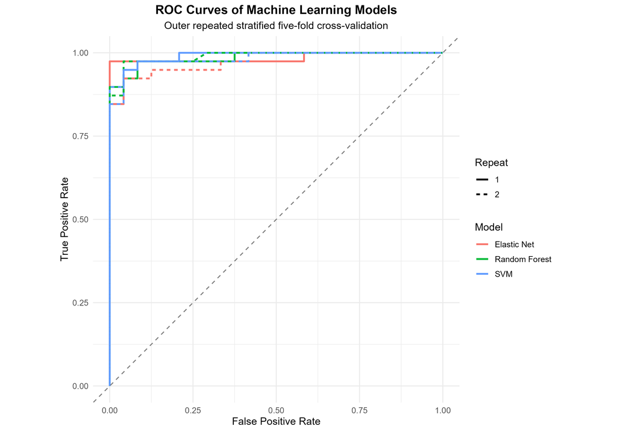

```r
# Display ROC curves
knitr::include_graphics(ml_roc_file)
```

```r
# Verify evaluation outputs
evaluation_files <- c(
  performance_file,
  performance_summary_file,
  ml_roc_file
)

stopifnot(
  nrow(performance_by_repeat) == 6,
  nrow(performance_summary) == 3,
  all(file.exists(evaluation_files)),
  all(file.info(evaluation_files)$size > 0)
)

cat("\nMachine learning evaluation completed successfully.\n")
```

```
##
## Machine learning evaluation completed successfully.
```